# Master Thesis

### 3.2.2 Random Forest

Before you execute the next chunk, you might consider to just import the resulting tables for your input parameters (if available) in section 5.1. The reason for that is that depending whether you use hyperparameter tuning and/or cross validation, the computation can take up to two hours if you only use one core (i.e. cluster == NULL)! But even with seven or eight clusters you might wait 40 minutes or so. Hence, consider just importing the resulting tables.

However, if no results are available for your input parameters, the predictions are calculated in the next chunk. We run the return predictions separately from the portfolio strategies for two reasons. First, the predictions (need to) stay the same for the different portfolio strategies. Second, by running the predictions only once, we reduce the computational effort dramatically (because the out-of-sample predictions need to be calculated only once [instead of the quantity of our portfolio strategies]) and we don’t have to set a seed every time we’re running the model.

*Note: The model will run with the input parameters you specified at the beginning of this chapter!*

```r
# If no Z-Score trans is wished
tmp <- ret
# If Z-score transformation is wished
if(trans.Z == T){
  tmp <- Z.TRANS(ret = ret, Names = Names, last = last)
}
# Initial number of training rows:
train.rows <- Train.Rows(ret = tmp, train.perc = train.perc)
# Compute EMAs with max. 5 years of data laying back for Macro variables:
macro.ema <- TRANS.MACRO(data = macro, lookback = lookback)
# All test values
y_test <- Test_DS(ret = tmp, train.rows = train.rows, horizon = horizon)
if(!is.null(clusters)){
  print("!!Attention: You set the variable clusters. Don't perform several other (complex) parallel tasks on your machine while the loop is running!!")
}
```

```
## [1] "!!Attention: You set the variable clusters. Don't perform several other (complex) parallel tasks on your machine while the loop is running!!"
```

```r
if(round(train.perc*nrow(ret)-lag,0) < (horizon+1)){
  print("!!ATTENTION: INTERFERENCE OF INITIAL TRAINING ROWS WITH TIME LAG AND HORIZON --> RANDOM FOREST CAN'T BE EXECUTED!!")
}
if((limit-lag) < (horizon+1)){
  print("!!ATTENTION: INTERFERENCE OF LIMIT WITH TIME LAG AND HORIZON --> RANDOM FOREST CAN'T BE EXECUTED!!")
}
t=1

## Start predictions:
while(t<nrow(y_test$y_test)){

  input <- Train_DS(ret = tmp, macro.ema = macro.ema, train.rows = train.rows,
                    lag = lag, limit = limit)

  res <- RANDOM_FOREST(input = input, horizon = horizon, y_test = y_test, counter =  t, old.forecasts = old.forecasts,
                       cum.perf = cum.perf, tune_grid = tune_grid, train_control = train_control, clusters = clusters,
                       limit = limit, n.trees = n.trees)

  t <- res$counter
  train.rows <- res$train.rows
  old.forecasts <- res$old.forecasts
  cum.perf <- res$cum.perf

}
```

```
## [1] "2014-08-29"
## [1] "2015-08-31"
## [1] "2016-08-31"
## [1] "2017-08-31"
## [1] "2018-08-31"
## [1] "2019-08-30"
## [1] "2020-08-31"
## [1] "2021-08-31"
## [1] "2022-08-31"
## [1] "2023-08-31"
```

```r
## Extract return predictions:
monthly.pred <- do.call(cbind, res$old.forecasts)
cumulative.pred <- do.call(cbind, res$cum.perf)

## Evaluation for monthly and cumulative return predictions:
eval <- EVAL(y_predictions = res$old.forecasts, y_actual = y_test$y_test,
             y_predictions.cum = res$cum.perf, y_actual.cum = y_test$y_test.cum)
eval <- do.call(rbind, eval)
round(eval,4)
```

```
##                     S&P 500 TRUST S&P Midcap 400 S&P Smallcap Technology
## monthly RMSE               0.0454         0.0549       0.0604     0.0585
## monthly Rsquared           0.0003         0.0001       0.0005     0.0061
## monthly MAE                0.0347         0.0407       0.0454     0.0462
## cumulative RMSE            0.1333         0.2007       0.2452     0.2015
## cumulative Rsquared        0.3221         0.3196       0.1870     0.2754
## cumulative MAE             0.0993         0.1225       0.1698     0.1525
##                     Financials Telecom Basic Materials Consumer Discretionary
## monthly RMSE            0.0558  0.0502          0.0634                 0.0536
## monthly Rsquared        0.0202  0.0012          0.0102                 0.0028
## monthly MAE             0.0420  0.0394          0.0496                 0.0400
## cumulative RMSE         0.2246  0.1849          0.2079                 0.1702
## cumulative Rsquared     0.4217  0.0154          0.1234                 0.2143
## cumulative MAE          0.1691  0.1484          0.1691                 0.1242
##                     Consumer Staples Energy Healthcare Industrials Utilities
## monthly RMSE                  0.0419 0.0963     0.0441      0.0535    0.0446
## monthly Rsquared              0.0026 0.0301     0.0172      0.0009    0.0012
## monthly MAE                   0.0313 0.0668     0.0350      0.0406    0.0355
## cumulative RMSE               0.1080 0.3723     0.1512      0.1702    0.1215
## cumulative Rsquared           0.0009 0.0713     0.0190      0.1799    0.3251
## cumulative MAE                0.0860 0.3069     0.1140      0.1046    0.1081
##                     Biotechnology Semiconductor Transportation Real Estate
## monthly RMSE               0.0669        0.0751         0.0631      0.0521
## monthly Rsquared           0.0066        0.0020         0.0005      0.0033
## monthly MAE                0.0509        0.0574         0.0508      0.0395
## cumulative RMSE            0.3052        0.2194         0.1985      0.1858
## cumulative Rsquared        0.0403        0.0002         0.0565      0.2376
## cumulative MAE             0.2096        0.1778         0.1609      0.1517
##                     S&P 500 Growth S&P 500 Value Y1-3 Treasury Bond
## monthly RMSE                0.0482        0.0471             0.0045
## monthly Rsquared            0.0041        0.0102             0.0007
## monthly MAE                 0.0378        0.0359             0.0033
## cumulative RMSE             0.1489        0.1586             0.0245
## cumulative Rsquared         0.0668        0.3934             0.0001
## cumulative MAE              0.1101        0.1055             0.0188
##                     Y7-10 Treasury Bond Y20+ Treasury Bond
## monthly RMSE                     0.0197             0.0430
## monthly Rsquared                 0.0002             0.0096
## monthly MAE                      0.0151             0.0335
## cumulative RMSE                  0.0966             0.2176
## cumulative Rsquared              0.0342             0.0449
## cumulative MAE                   0.0840             0.1750
##                     Tips Bond (Inflation) Inv Grade Corporate Bond
## monthly RMSE                       0.0149                   0.0241
## monthly Rsquared                   0.0212                   0.0113
## monthly MAE                        0.0106                   0.0175
## cumulative RMSE                    0.0611                   0.0976
## cumulative Rsquared                0.0056                   0.0023
## cumulative MAE                     0.0515                   0.0743
##                     High Yield Corporate Bond Gold Shares Emerging Markets
## monthly RMSE                           0.0232      0.0434           0.0513
## monthly Rsquared                       0.0004      0.0057           0.0057
## monthly MAE                            0.0166      0.0336           0.0404
## cumulative RMSE                        0.0591      0.2309           0.1626
## cumulative Rsquared                    0.0329      0.0468           0.0066
## cumulative MAE                         0.0483      0.1917           0.1523
```

```r
rowMeans(eval)
```

```
##        monthly RMSE    monthly Rsquared         monthly MAE     cumulative RMSE
##         0.048119490         0.006478516         0.036675110         0.172512926
## cumulative Rsquared      cumulative MAE
##         0.127526950         0.132818628
```

Note that if you set a “limit”, even though the index “train.rows” returns all rows (for the last iteration), for the computation only all the last “limit” rows were used, this is because the training set is created within the function “Train_DS” which adjusts the training data set according to their limit, but doesn’t return the adjusted “train.rows”. Hence, the desired number of rows (according to the variable “limit”) is used for the training data set.

## 3.3 Backtests

In this subsections the specific portfolios are formed upon the return predictions in subsection 3.2 (if there are any). Their performance is evaluated upon the out-of-sample (backtesting) period determined by the input variable “train.perc” (i.e. the other half will be used as the backtesting period). As before we use a walk forward approach with or without a “lookback” limit defined by the input variable “limit”.  
A new portfolio is formed after each “horizon” (see input parameters) months (i.e. after “horizon” months a rebalancing is performed).  
Note that all performance-based evaluations for the various strategies (section 3.1.4) are also performed in this subsections after the backtests are executed.

### 3.3.1 Benchmarks

For that, we start with the (“easier”) benchmark strategies.

#### 3.3.1.1 Buy-and-Hold MSCI World

Since, the buy-and-hold strategy is only evaluated for one ETF and we know the time frame of the backtesting period, no loop is required and the performance computation can be done in a vectorized way. Also note, that here we have no information about the turnover because we only buy the asset once and then no rebalancing is performed. Hence, this measure becomes superfluous.

```r
train.rows <- Train.Rows(ret = ret, train.perc = train.perc)
y_test <- Test_DS(ret = ret, train.rows = train.rows, horizon = horizon)
BT.Dates <- index(y_test$y_test)
RF <- rf

## Start the backtest
res.bench <- B.A.H(bench = bench, BT.Dates = BT.Dates, trans.costs = trans.costs, TER.monthly = TER.monthly, RF = rf, VaR.CI = VaR.CI)

## Summary statistics:
stat.B.A.H <- do.call(rbind, res.bench)[,-ncol(do.call(rbind, res.bench))]
stat.B.A.H
```

```
##          mean.ret.ann sd.ann    SR.ann    SR.loss     SortinoR.ann VaR.ann
## no costs 0.1239609    0.1155394 0.9558639 0           1.438309     0.1826001
## 10bps    0.1183064    0.115518  0.9070918 -0.05102417 1.355605     0.1840402
## 20bps    0.1181918    0.1154975 0.9062604 -0.05189398 1.354187     0.1840402
## 30bps    0.1180772    0.1154779 0.9054218 -0.05277131 1.352769     0.1840402
## 40bps    0.1179626    0.1154592 0.904576  -0.05365617 1.351351     0.1840402
## 50bps    0.1178481    0.1154414 0.903723  -0.05454853 1.349933     0.1840402
##          MaxDraw
## no costs 0.1603305
## 10bps    0.1631826
## 20bps    0.1631826
## 30bps    0.1631826
## 40bps    0.1631826
## 50bps    0.1631826
```

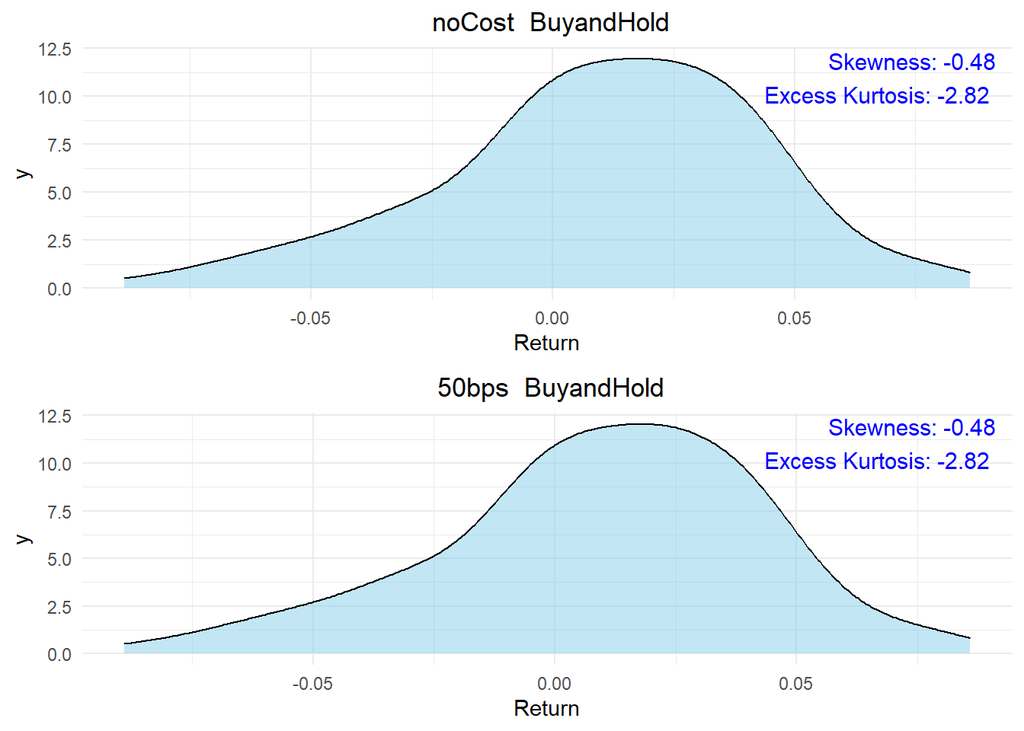

```r
## Distribution of returns:
tmp.nocost <- res.bench$`no costs`$ret.noCosts
colnames(tmp.nocost) <- "BuyandHold.noCost"
tmp.50bps <- res.bench$`50bps`$ret.Costs
colnames(tmp.50bps) <- "BuyandHold.50bps"
DISTRIBUTION(res = as.data.frame(do.call(cbind,list(BuyandHold.NoCosts = tmp.nocost,
                                                    BuyandHold.50bps = tmp.50bps))))
```

```r
## Positional exposure:
# == Is always one for the single ETF case
```

Note that the Maximum Drawdown is the same for all transaction costs because the first period of the MDD doesn’t start in the first observation (month). Only then the different transaction costs would have an influence on the MDD. Also since the total costs (TER) stay the same for all return vectors they also don’t affect the MDD.

#### 3.3.1.2 50-50 MSCI World & 20Y+ US Gov Bond

The backtest for the 50-50 benchmark is executed via the LONG.ONLY function defined in section 3.1.5.3.

```r
train.rows <- Train.Rows(ret = ret, train.perc = train.perc)
y_test <- Test_DS(ret = ret, train.rows = train.rows, horizon = horizon)
BT.Dates <- index(y_test$y_test)
B.a.H <- bench[BT.Dates,]
B.a.H <- cbind(B.a.H, y_test$y_test[,"Y20+ Treasury Bond"])
colnames(B.a.H) <- c("MSCI World", "Y20+ Treasury Bond")
counter = 1
t = 1
portf.EW.all <- list()
portf.RW.all <- list()
all.ret.mon.portf.EW <- NULL
all.ret.mon.portf.RW <- NULL
res.50_50 <- NULL

## Start backtest:
while(counter<nrow(y_test$y_test)){

  #print(t)

  res.50_50 <- LONG.ONLY(y_test = B.a.H, cum.pred = NULL, use.long.only = NULL, counter = counter,
                         t = t, horizon = horizon, portf.EW.all = portf.EW.all, portf.RW.all = list(),
                         all.ret.mon.portf.EW = all.ret.mon.portf.EW, all.ret.mon.portf.RW = NULL, fix.tc = fix.tc,
                         trans.costs = trans.costs, TER.monthly = TER.monthly, res.all = res.50_50)
  t <- res.50_50$t
  counter <- res.50_50$counter
  portf.EW.all <- res.50_50$portf.EW.all
  all.ret.mon.portf.EW <- res.50_50$ret.portf.EW$`No costs`$`Monthly Portfolio Return`

}

## Summary statistics:
stat.B.A.H <- STATISTICS(res = res.50_50$ret.portf.EW, RF = rf, VaR.CI = VaR.CI, horizon = horizon, trans.costs = trans.costs)
stat.B.A.H
```

```
##          ret.ann    sd.ann     SR.ann    SR.loss     SortinoR.ann VaR.ann
## no costs 0.06282484 0.09465591 0.5139018 0           0.788287     0.1510953
## 10bps    0.05922805 0.09461809 0.4760934 -0.07357131 0.7260919    0.1520316
## 20bps    0.05905613 0.09458142 0.4744603 -0.07674906 0.7233316    0.1520316
## 30bps    0.05888423 0.09454587 0.4728206 -0.07993981 0.7205715    0.1520316
## 40bps    0.05871237 0.09451147 0.4711742 -0.08314348 0.7178116    0.1520316
## 50bps    0.05854052 0.0944782  0.4695212 -0.08635997 0.715052     0.1520316
##          Max.Draw  Turnover.norm
## no costs 0.2517422 0.007518172
## 10bps    0.2563563 0.003719231
## 20bps    0.2564722 0.003719243
## 30bps    0.2565882 0.003719255
## 40bps    0.2567041 0.003719266
## 50bps    0.25682   0.003719278
```

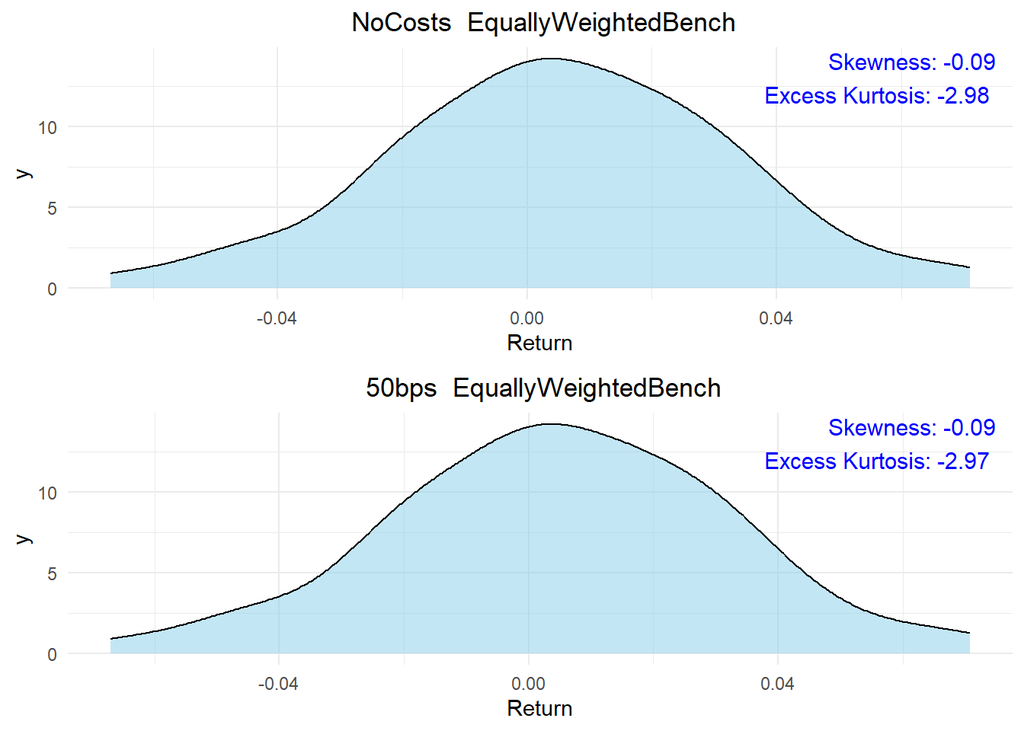

```r
## Distribution of returns:
# ATTENTION: THE NAMING OF THE VECTORS IS ESSENTIAL AND HAS TO FOLLOW THE SEQUENCE "WEIGHTINGTYPE.COSTS"
DISTRIBUTION(res = as.data.frame(do.call(cbind,list(EquallyWeightedBench.NoCosts = res.50_50$ret.portf.EW$`No costs`$`Monthly Portfolio Return`,
                                                    EquallyWeightedBench.50bps = res.50_50$ret.portf.EW$`50bps`$`Monthly Portfolio Return`))))
```

```r
## Positional exposure:
EXPOSURE(weights.init = portf.EW.all, horizon = horizon, y_test = y_test$y_test, asset.classes = asset.classes)
```

```
## $Exposure.ETFs
##                          ETF Exposure  AssetClass
## 1              S&P 500 TRUST      0.0      equity
## 2             S&P Midcap 400      0.0      equity
## 3               S&P Smallcap      0.0      equity
## 4                 Technology      0.0      equity
## 5                 Financials      0.0      equity
## 6                    Telecom      0.0      equity
## 7            Basic Materials      0.0      equity
## 8     Consumer Discretionary      0.0      equity
## 9           Consumer Staples      0.0      equity
## 10                    Energy      0.0      equity
## 11                Healthcare      0.0      equity
## 12               Industrials      0.0      equity
## 13                 Utilities      0.0      equity
```

[output cut: 17 more lines]

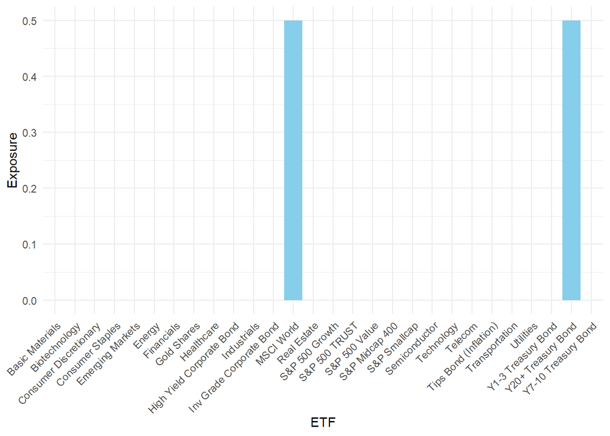

```
##
## $Exposure.asset.classes
## # A tibble: 4 × 2
##   AssetClass  TotalExposure
##   <chr>               <dbl>
## 1 bonds                 0.5
## 2 commodities           0
## 3 equity                0.5
## 4 real.estate           0
##
## $Exposure.asset.classes.plot
```

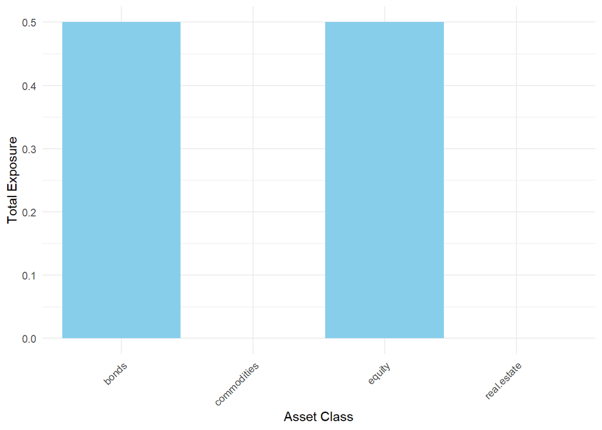

### 3.3.2 Prevailing Mean Method

Next, we are going to test the portfolios which are built upon the return predictions of the Prevailing Mean method. Therefore, we are evaluating both weighting methods (equally and rank weighted) for the long-only and long-short portfolios as well as the minimum variance optimization procedure.

#### 3.3.2.1 Long-Only

```r
# If no Z-Score trans is wished
tmp <- ret
# If Z-score transformation is wished
if(trans.Z == T){
  tmp <- Z.TRANS(ret = ret, Names = Names, last = last)
}
train.rows <- Train.Rows(ret = tmp, train.perc = train.perc)
dates <- index(Test_DS(ret = tmp, train.rows = train.rows, horizon = horizon)$y_test)
y_test <- Test_DS(ret = ret, train.rows = train.rows, horizon = horizon)
counter = 1
t = 1
portf.EW.all <- list()
portf.RW.all <- list()
all.ret.mon.portf.EW <- NULL
all.ret.mon.portf.RW <- NULL
res.PR.L.O <- NULL

## Start the backtest
while(counter < nrow(y_test$y_test[dates,])){

  #print(t)

  res.PR.L.O <- LONG.ONLY(y_test = y_test$y_test[dates,], cum.pred = mean.ret.cum.all, use.long.only = use.long.only,
                          counter = counter, t = t, horizon = horizon, portf.EW.all = portf.EW.all, portf.RW.all = portf.RW.all,
                          all.ret.mon.portf.EW = all.ret.mon.portf.EW, all.ret.mon.portf.RW = all.ret.mon.portf.RW, fix.tc = fix.tc,
                          trans.costs = trans.costs, TER.monthly = TER.monthly, res.all = res.PR.L.O)

  t <- res.PR.L.O$t
  counter <- res.PR.L.O$counter
  # Extract initial weights
  portf.EW.all <- res.PR.L.O$portf.EW.all
  portf.RW.all <- res.PR.L.O$portf.RW.all
  # All other performance results
  all.ret.mon.portf.EW <- res.PR.L.O$ret.portf.EW$`No costs`$`Monthly Portfolio Return`
  all.ret.mon.portf.RW <- res.PR.L.O$ret.portf.RW$`No costs`$`Monthly Portfolio Return`
}

## Summary statistics:
# EW:
stat.EW.L.O.PR <- STATISTICS(res = res.PR.L.O$ret.portf.EW, RF = rf, VaR.CI = VaR.CI, horizon = horizon, trans.costs = trans.costs)
# RW:
stat.RW.L.O.PR <- STATISTICS(res = res.PR.L.O$ret.portf.RW, RF = rf, VaR.CI = VaR.CI, horizon = horizon, trans.costs = trans.costs)
LO.PR <- list(Equally.Weighted.L.O = stat.EW.L.O.PR, Rank.Weighted.L.O = stat.RW.L.O.PR)
LO.PR
```

```
## $Equally.Weighted.L.O
##          ret.ann   sd.ann    SR.ann    SR.loss     SortinoR.ann VaR.ann
## no costs 0.1210583 0.1698402 0.6292813 0           0.8678031    0.3100597
## 10bps    0.1166498 0.1698728 0.6032092 -0.04143155 0.8301252    0.3109617
## 20bps    0.1158831 0.1699098 0.5985652 -0.04881146 0.8234751    0.3109617
## 30bps    0.1151169 0.1699499 0.5939153 -0.05620058 0.8168245    0.3109617
## 40bps    0.1143511 0.1699931 0.58926   -0.06359848 0.8101737    0.3109617
## 50bps    0.1135859 0.1700394 0.5845994 -0.07100473 0.8035231    0.3109617
##          Max.Draw  Turnover.norm
## no costs 0.3147788 0.0485995
## 10bps    0.3169234 0.04657196
## 20bps    0.3173942 0.04657092
## 30bps    0.3178649 0.04657
## 40bps    0.3183357 0.04656909
## 50bps    0.3188065 0.04656817
##
## $Rank.Weighted.L.O
##          ret.ann   sd.ann    SR.ann    SR.loss     SortinoR.ann VaR.ann
## no costs 0.1471416 0.196671  0.676056  0           0.9240133    0.3796096
## 10bps    0.1424518 0.1966877 0.6521549 -0.03535381 0.8897617    0.380631
## 20bps    0.1417921 0.1967044 0.6487452 -0.04039724 0.8848777    0.380631
## 30bps    0.1411327 0.196723  0.6453321 -0.04544583 0.8799942    0.380631
## 40bps    0.1404736 0.1967434 0.6419156 -0.05049945 0.8751113    0.380631
## 50bps    0.139815  0.1967656 0.6384957 -0.05555795 0.870229     0.380631
##          Max.Draw  Turnover.norm
## no costs 0.370881  0.03690927
## 10bps    0.3727705 0.03642441
## 20bps    0.3730511 0.03642386
## 30bps    0.3733318 0.03642331
## 40bps    0.3736124 0.03642276
## 50bps    0.3738931 0.03642221
```

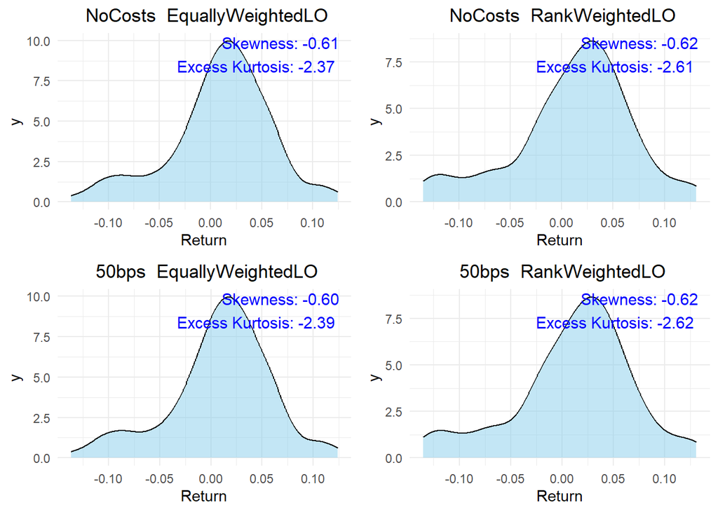

```r
## Distribution of returns:
# ATTENTION: THE NAMING OF THE VECTORS IS ESSENTIAL AND HAS TO FOLLOW THE SEQUENCE "WEIGHTINGTYPE.COSTS"
DISTRIBUTION(res = as.data.frame(do.call(cbind,list(EquallyWeightedLO.NoCosts = res.PR.L.O$ret.portf.EW$`No costs`$`Monthly Portfolio Return`,
                                                    EquallyWeightedLO.50bps = res.PR.L.O$ret.portf.EW$`50bps`$`Monthly Portfolio Return`,
                                                    RankWeightedLO.NoCosts = res.PR.L.O$ret.portf.RW$`No costs`$`Monthly Portfolio Return`,
                                                    RankWeightedLO.50bps = res.PR.L.O$ret.portf.RW$`50bps`$`Monthly Portfolio Return`))))
```

```r
## Positional exposure:
# EW:
EXPOSURE(weights.init = portf.EW.all, horizon = horizon, y_test = y_test$y_test, asset.classes = asset.classes)
```

```
## $Exposure.ETFs
##                          ETF   Exposure  AssetClass
## 1              S&P 500 TRUST 0.05714286      equity
## 2             S&P Midcap 400 0.04285714      equity
## 3               S&P Smallcap 0.04285714      equity
## 4                 Technology 0.10000000      equity
## 5                 Financials 0.01428571      equity
## 6                    Telecom 0.00000000      equity
## 7            Basic Materials 0.00000000      equity
## 8     Consumer Discretionary 0.12857143      equity
## 9           Consumer Staples 0.05714286      equity
## 10                    Energy 0.00000000      equity
## 11                Healthcare 0.11428571      equity
## 12               Industrials 0.07142857      equity
## 13                 Utilities 0.01428571      equity
```

[output cut: 16 more lines]

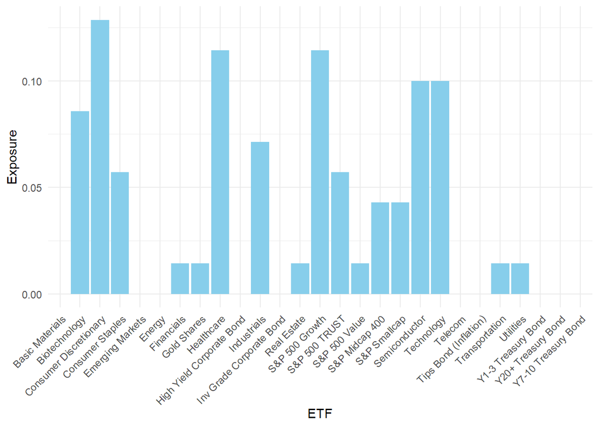

```
##
## $Exposure.asset.classes
## # A tibble: 4 × 2
##   AssetClass  TotalExposure
##   <chr>               <dbl>
## 1 bonds              0
## 2 commodities        0.0143
## 3 equity             0.971
## 4 real.estate        0.0143
##
## $Exposure.asset.classes.plot
```

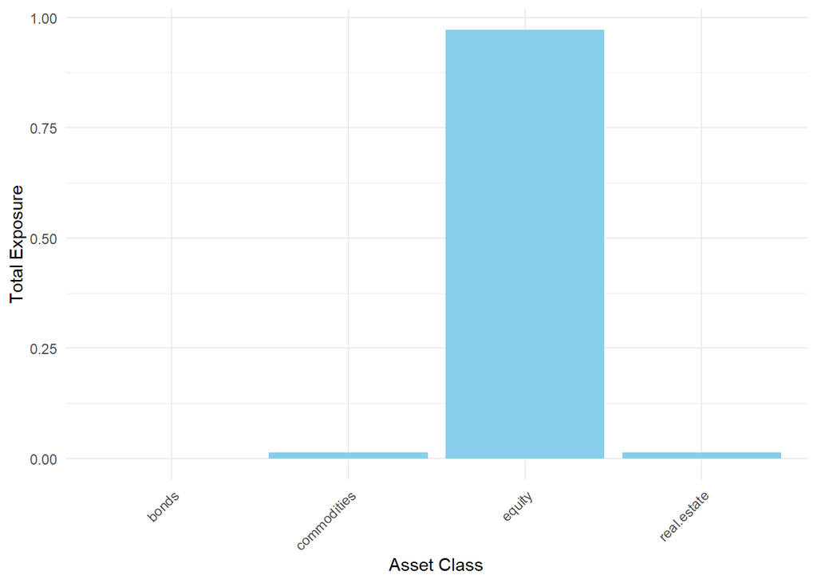

```r
# RW:
EXPOSURE(weights.init = portf.RW.all, horizon = horizon, y_test = y_test$y_test, asset.classes = asset.classes)
```

```
## $Exposure.ETFs
##                          ETF    Exposure  AssetClass
## 1              S&P 500 TRUST 0.033425161      equity
## 2             S&P Midcap 400 0.017447199      equity
## 3               S&P Smallcap 0.016528926      equity
## 4                 Technology 0.110560147      equity
## 5                 Financials 0.006427916      equity
## 6                    Telecom 0.000000000      equity
## 7            Basic Materials 0.000000000      equity
## 8     Consumer Discretionary 0.108631772      equity
## 9           Consumer Staples 0.032782369      equity
## 10                    Energy 0.000000000      equity
## 11                Healthcare 0.096418733      equity
## 12               Industrials 0.029384757      equity
## 13                 Utilities 0.005509642      equity
```

[output cut: 16 more lines]

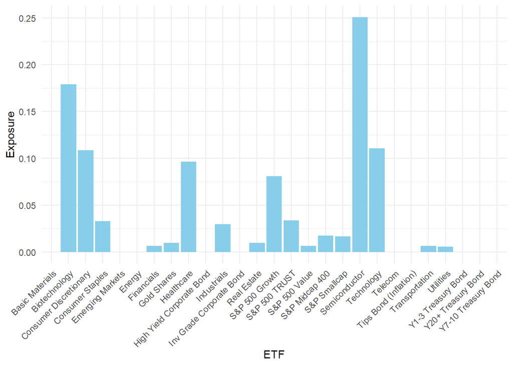

```
##
## $Exposure.asset.classes
## # A tibble: 4 × 2
##   AssetClass  TotalExposure
##   <chr>               <dbl>
## 1 bonds             0
## 2 commodities       0.00964
## 3 equity            0.981
## 4 real.estate       0.00964
##
## $Exposure.asset.classes.plot
```

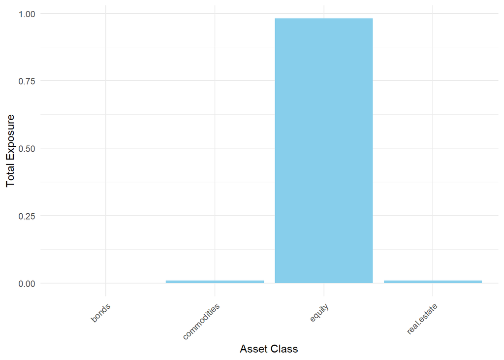

#### 3.3.2.2 Long-Short Portfolio

```r
train.rows <- Train.Rows(ret = ret, train.perc = train.perc)
y_test <- Test_DS(ret = ret, train.rows = train.rows, horizon = horizon)
counter = 1
t = 1
portf.EW.all <- list()
portf.RW.all <- list()
all.ret.mon.portf.EW <- NULL
all.ret.mon.portf.RW <- NULL
res.PR.L.S <- NULL

while(counter < nrow(y_test$y_test)){

  #print(t)

  res.PR.L.S <- LONG.SHORT(y_test = y_test$y_test, cum.pred = mean.ret.cum.all, disc.positive = disc.positive,
                           use.long.short = use.long.short, lend = lend, counter = counter, t = t, horizon = horizon,
                           portf.EW.all = portf.EW.all, portf.RW.all = portf.RW.all, all.ret.mon.portf.EW = all.ret.mon.portf.EW,
                           all.ret.mon.portf.RW = all.ret.mon.portf.RW, fix.tc = fix.tc, trans.costs = trans.costs,
                           TER.monthly = TER.monthly, res.all = res.PR.L.S)

  t <- res.PR.L.S$t
  counter <- res.PR.L.S$counter
  # Extract initial weights
  portf.EW.all <- res.PR.L.S$portf.EW.all
  portf.RW.all <- res.PR.L.S$portf.RW.all
  # All other performance results
  all.ret.mon.portf.EW <- res.PR.L.S$ret.portf.EW$`No costs`$`Monthly Portfolio Return`
  all.ret.mon.portf.RW <- res.PR.L.S$ret.portf.RW$`No costs`$`Monthly Portfolio Return`
}

## Summary statistics:
# EW:
stat.EW.L.S.PR <- STATISTICS(res = res.PR.L.S$ret.portf.EW, RF = rf, VaR.CI = VaR.CI, horizon = horizon, trans.costs = trans.costs)
# RW:
stat.RW.L.S.PR <- STATISTICS(res = res.PR.L.S$ret.portf.RW, RF = rf, VaR.CI = VaR.CI, horizon = horizon, trans.costs = trans.costs)
LS.PR <- list(Equally.Weighted.L.S = stat.EW.L.S.PR, Rank.Weighted.L.S = stat.RW.L.S.PR)
LS.PR
```

```
## $Equally.Weighted.L.S
##          ret.ann    sd.ann     SR.ann    SR.loss    SortinoR.ann VaR.ann
## no costs 0.04579881 0.0578145  0.5468838 0          0.7879861    0.1069369
## 10bps    0.04102177 0.05788357 0.4637028 -0.1520998 0.6612367    0.1078858
## 20bps    0.03962621 0.05797875 0.4388713 -0.1975054 0.6238223    0.1078858
## 30bps    0.03823237 0.05810462 0.4139321 -0.2431078 0.5864627    0.1078858
## 40bps    0.03684025 0.05826099 0.3889266 -0.2888313 0.5492394    0.1078858
## 50bps    0.03544985 0.0584476  0.3638961 -0.3346007 0.5122427    0.1078858
##          Max.Draw  Turnover.norm
## no costs 0.1041235 0.1098691
## 10bps    0.1056366 0.1089031
## 20bps    0.1056366 0.1089026
## 30bps    0.1056366 0.1089021
## 40bps    0.1056366 0.1089016
## 50bps    0.1056366 0.1089011
##
## $Rank.Weighted.L.S
##          ret.ann    sd.ann     SR.ann    SR.loss    SortinoR.ann VaR.ann
## no costs 0.05998367 0.07459995 0.6139772 0          0.8781371    0.1457997
## 10bps    0.05520351 0.07470351 0.5491376 -0.1056059 0.7784989    0.146652
## 20bps    0.05385323 0.07482333 0.530212  -0.1364304 0.7496137    0.146652
## 30bps    0.05250458 0.07496458 0.5112224 -0.1673592 0.7208105    0.146652
## 40bps    0.05115754 0.07512715 0.4921861 -0.1983641 0.6921194    0.146652
## 50bps    0.04981212 0.0753109  0.4731204 -0.2294169 0.663569     0.146652
##          Max.Draw  Turnover.norm
## no costs 0.1140131 0.103665
## 10bps    0.1158278 0.1033477
## 20bps    0.1170413 0.1033459
## 30bps    0.1182545 0.1033442
## 40bps    0.1194677 0.1033425
## 50bps    0.1206807 0.1033408
```

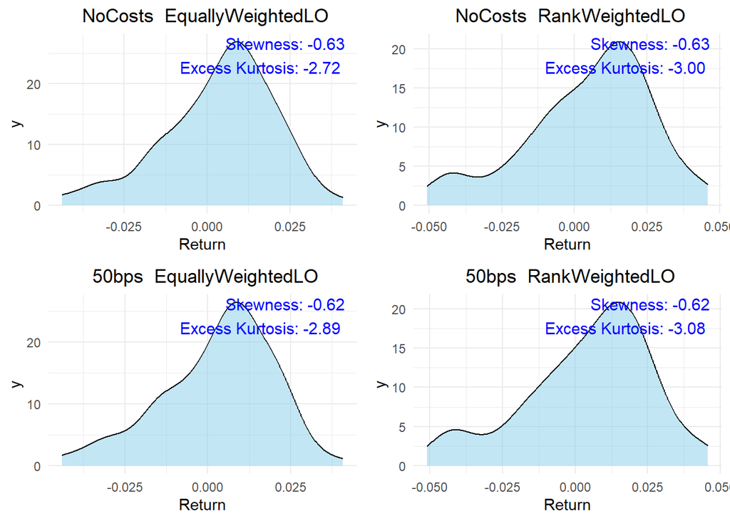

```r
## Distribution of returns:
# ATTENTION: THE NAMING OF THE VECTORS IS ESSENTIAL AND HAS TO FOLLOW THE SEQUENCE "WEIGHTINGTYPE.COSTS"
DISTRIBUTION(res = as.data.frame(do.call(cbind,list(EquallyWeightedLO.NoCosts = res.PR.L.S$ret.portf.EW$`No costs`$`Monthly Portfolio Return`,
                                                    EquallyWeightedLO.50bps = res.PR.L.S$ret.portf.EW$`50bps`$`Monthly Portfolio Return`,
                                                    RankWeightedLO.NoCosts = res.PR.L.S$ret.portf.RW$`No costs`$`Monthly Portfolio Return`,
                                                    RankWeightedLO.50bps = res.PR.L.S$ret.portf.RW$`50bps`$`Monthly Portfolio Return`))))
```

```r
## Positional exposure:
# EW:
EXPOSURE(weights.init = portf.EW.all, horizon = horizon, y_test = y_test$y_test, asset.classes = asset.classes)
```

```
## $Exposure.ETFs
##                          ETF     Exposure  AssetClass
## 1              S&P 500 TRUST  0.028571429      equity
## 2             S&P Midcap 400  0.021428571      equity
## 3               S&P Smallcap  0.021428571      equity
## 4                 Technology  0.050000000      equity
## 5                 Financials -0.007142857      equity
## 6                    Telecom -0.035714286      equity
## 7            Basic Materials -0.014285714      equity
## 8     Consumer Discretionary  0.064285714      equity
## 9           Consumer Staples  0.028571429      equity
## 10                    Energy -0.050000000      equity
## 11                Healthcare  0.057142857      equity
## 12               Industrials  0.035714286      equity
## 13                 Utilities  0.007142857      equity
```

[output cut: 16 more lines]

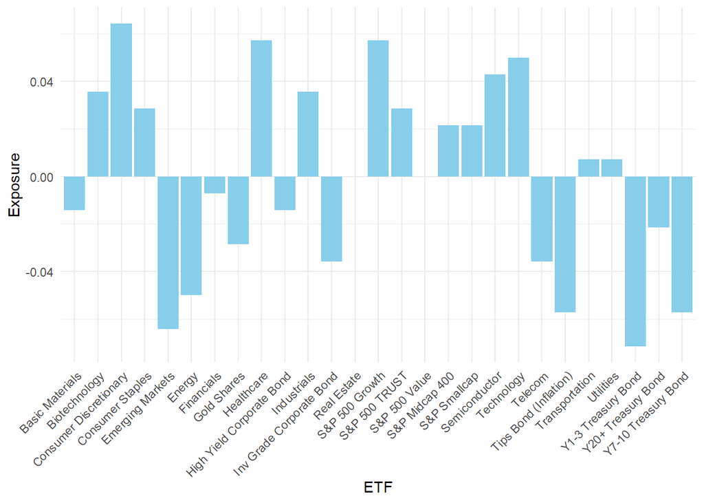

```
##
## $Exposure.asset.classes
## # A tibble: 4 × 2
##   AssetClass  TotalExposure
##   <chr>               <dbl>
## 1 bonds             -0.257
## 2 commodities       -0.0286
## 3 equity             0.286
## 4 real.estate        0
##
## $Exposure.asset.classes.plot
```

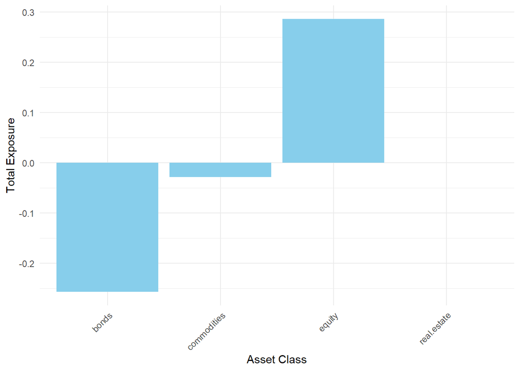

```r
# RW:
EXPOSURE(weights.init = portf.RW.all, horizon = horizon, y_test = y_test$y_test, asset.classes = asset.classes)
```

```
## $Exposure.ETFs
##                          ETF     Exposure  AssetClass
## 1              S&P 500 TRUST  0.016712580      equity
## 2             S&P Midcap 400  0.008723600      equity
## 3               S&P Smallcap  0.008264463      equity
## 4                 Technology  0.055280073      equity
## 5                 Financials -0.018824610      equity
## 6                    Telecom -0.017539027      equity
## 7            Basic Materials -0.023140496      equity
## 8     Consumer Discretionary  0.054315886      equity
## 9           Consumer Staples  0.016391185      equity
## 10                    Energy -0.034435262      equity
## 11                Healthcare  0.048209366      equity
## 12               Industrials  0.014692378      equity
## 13                 Utilities  0.002754821      equity
```

[output cut: 16 more lines]

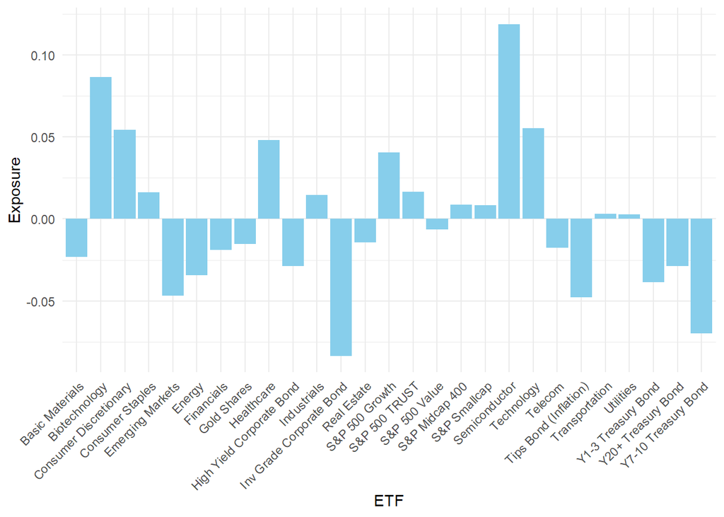

```
##
## $Exposure.asset.classes
## # A tibble: 4 × 2
##   AssetClass  TotalExposure
##   <chr>               <dbl>
## 1 bonds             -0.298
## 2 commodities       -0.0152
## 3 equity             0.327
## 4 real.estate       -0.0145
##
## $Exposure.asset.classes.plot
```

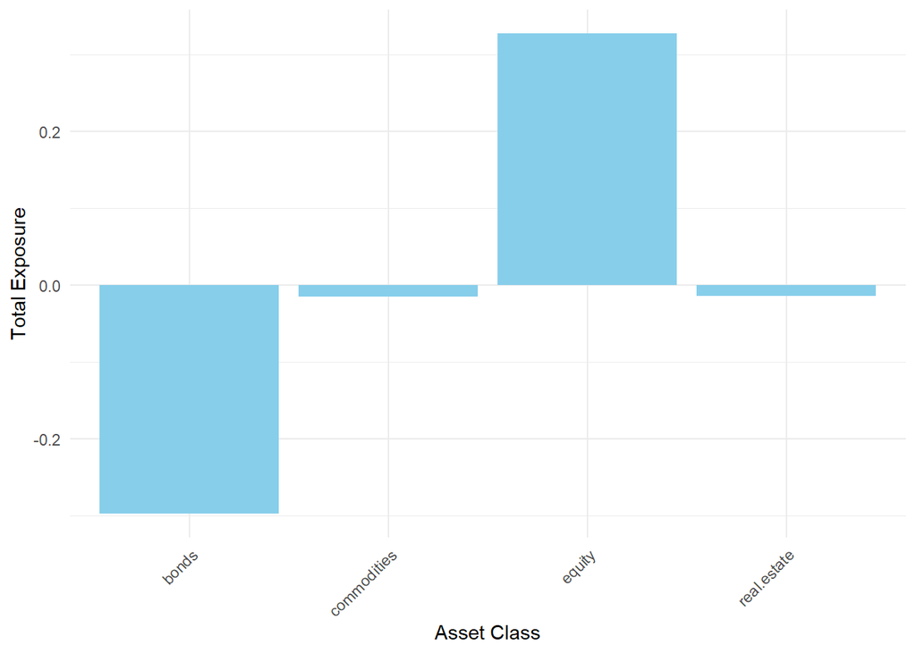

#### 3.3.2.3 Minimum Variance

Now the ETFs are pre-selected according to the Prevailing Mean model.

```r
train.rows <- Train.Rows(ret = ret, train.perc = train.perc)
y_test <- Test_DS(ret = ret, train.rows = train.rows, horizon = horizon)
counter = 1
t = 1
portf.sample.all <- list()
portf.shrink.all <- list()
all.ret.mon.portf.sample <- NULL
all.ret.mon.portf.shrink <- NULL
res.MV.PR <- NULL

while(counter < nrow(y_test$y_test)){

  #print(t)

  res.MV.PR <- MIN.VAR(ret = ret, train.rows = train.rows, y_test = y_test$y_test, cum.pred = mean.ret.cum.all,
                       use.minvar = use.minvar,counter = counter, t = t, horizon = horizon,
                       portf.shrink.all = portf.shrink.all, portf.sample.all = portf.sample.all,trans.costs = trans.costs,
                       TER.monthly = TER.monthly, all.ret.mon.portf.shrink = all.ret.mon.portf.shrink,
                       all.ret.mon.portf.sample = all.ret.mon.portf.sample, limit = limit, fix.tc = fix.tc,
                       min.max = min.max, res.all = res.MV.PR)

  train.rows <- res.MV.PR$train.rows
  t <- res.MV.PR$t
  counter <- res.MV.PR$counter
  # Extract initial weights
  portf.sample.all <- res.MV.PR$portf.sample.all
  portf.shrink.all <- res.MV.PR$portf.shrink.all
  # All other performance results
  all.ret.mon.portf.sample<- res.MV.PR$ret.portf.sample$`No costs`$`Monthly Portfolio Return`
  all.ret.mon.portf.shrink <- res.MV.PR$ret.portf.shrink$`No costs`$`Monthly Portfolio Return`
}

## Summary statistics:
# EW:
stat.MV.sample.PR <- STATISTICS(res = res.MV.PR$ret.portf.sample, RF = rf, VaR.CI = VaR.CI, horizon = horizon, trans.costs = trans.costs)
# RW:
stat.MV.shrink.PR <- STATISTICS(res = res.MV.PR$ret.portf.shrink, RF = rf, VaR.CI = VaR.CI, horizon = horizon, trans.costs = trans.costs)
MV.PR <- list(sample.MV = stat.MV.sample.PR, shrink.MV = stat.MV.shrink.PR)
MV.PR
```

```
## $sample.MV
##          ret.ann    sd.ann    SR.ann    SR.loss     SortinoR.ann VaR.ann
## no costs 0.1078791  0.1432758 0.6539699 0           0.9247974    0.2505791
## 10bps    0.1035179  0.143318  0.6233478 -0.04682504 0.8791657    0.2512818
## 20bps    0.1023936  0.1433474 0.6153762 -0.05901458 0.8674428    0.2512818
## 30bps    0.1012702  0.1433862 0.607375  -0.07124936 0.8556828    0.2512818
## 40bps    0.1001479  0.1434345 0.5993459 -0.0835269  0.8438888    0.2512818
## 50bps    0.09902651 0.1434921 0.5912904 -0.09584469 0.8320641    0.2512818
##          Max.Draw  Turnover.norm
## no costs 0.2039364 0.07626545
## 10bps    0.2070349 0.07767737
## 20bps    0.2084854 0.07767952
## 30bps    0.2099358 0.07768167
## 40bps    0.2113863 0.07768383
## 50bps    0.2128368 0.07768598
##
## $shrink.MV
##          ret.ann    sd.ann    SR.ann    SR.loss     SortinoR.ann VaR.ann
## no costs 0.1050924  0.1455802 0.6244765 0           0.8770096    0.2687203
## 10bps    0.1006928  0.1456349 0.5940323 -0.04875153 0.832151     0.2694567
## 20bps    0.09964356 0.1456796 0.5866474 -0.06057728 0.8214395    0.2694567
## 30bps    0.09859521 0.1457324 0.5792413 -0.07243697 0.8106982    0.2694567
## 40bps    0.09754774 0.1457931 0.5718152 -0.08432859 0.7999296    0.2694567
## 50bps    0.09650114 0.1458619 0.5643706 -0.09625007 0.7891363    0.2694567
##          Max.Draw  Turnover.norm
## no costs 0.2190232 0.06984228
## 10bps    0.2220073 0.07150062
## 20bps    0.2233668 0.07150209
## 30bps    0.2247264 0.07150357
## 40bps    0.2260859 0.07150504
## 50bps    0.2274455 0.07150652
```

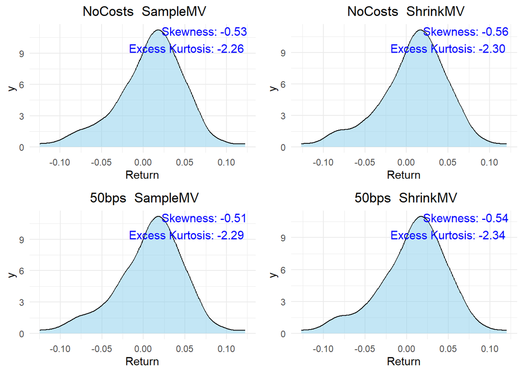

```r
## Distribution of returns:
# ATTENTION: THE NAMING OF THE VECTORS IS ESSENTIAL AND HAS TO FOLLOW THE SEQUENCE "WEIGHTINGTYPE.COSTS"
DISTRIBUTION(res = as.data.frame(do.call(cbind,list(SampleMV.NoCosts = res.MV.PR$ret.portf.sample$`No costs`$`Monthly Portfolio Return`,
                                                    SampleMV.50bps = res.MV.PR$ret.portf.sample$`50bps`$`Monthly Portfolio Return`,
                                                    ShrinkMV.NoCosts = res.MV.PR$ret.portf.shrink$`No costs`$`Monthly Portfolio Return`,
                                                    ShrinkMV.50bps = res.MV.PR$ret.portf.shrink$`50bps`$`Monthly Portfolio Return`))))
```

```r
## Positional exposure:
# EW:
EXPOSURE(weights.init = portf.sample.all, horizon = horizon, y_test = y_test$y_test, asset.classes = asset.classes)
```

```
## $Exposure.ETFs
##                          ETF      Exposure  AssetClass
## 1              S&P 500 TRUST  1.679148e-01      equity
## 2             S&P Midcap 400  3.083222e-17      equity
## 3               S&P Smallcap  1.297185e-17      equity
## 4                 Technology -3.484754e-17      equity
## 5                 Financials  2.132367e-02      equity
## 6                    Telecom  0.000000e+00      equity
## 7            Basic Materials  0.000000e+00      equity
## 8     Consumer Discretionary  1.854519e-03      equity
## 9           Consumer Staples  2.197844e-01      equity
## 10                    Energy  0.000000e+00      equity
## 11                Healthcare  2.608617e-01      equity
## 12               Industrials  1.030453e-18      equity
## 13                 Utilities  4.816994e-02      equity
```

[output cut: 16 more lines]

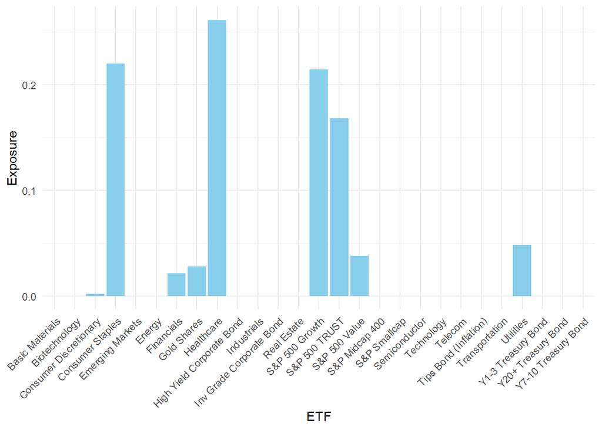

```
##
## $Exposure.asset.classes
## # A tibble: 4 × 2
##   AssetClass  TotalExposure
##   <chr>               <dbl>
## 1 bonds              0
## 2 commodities        0.0276
## 3 equity             0.972
## 4 real.estate        0
##
## $Exposure.asset.classes.plot
```

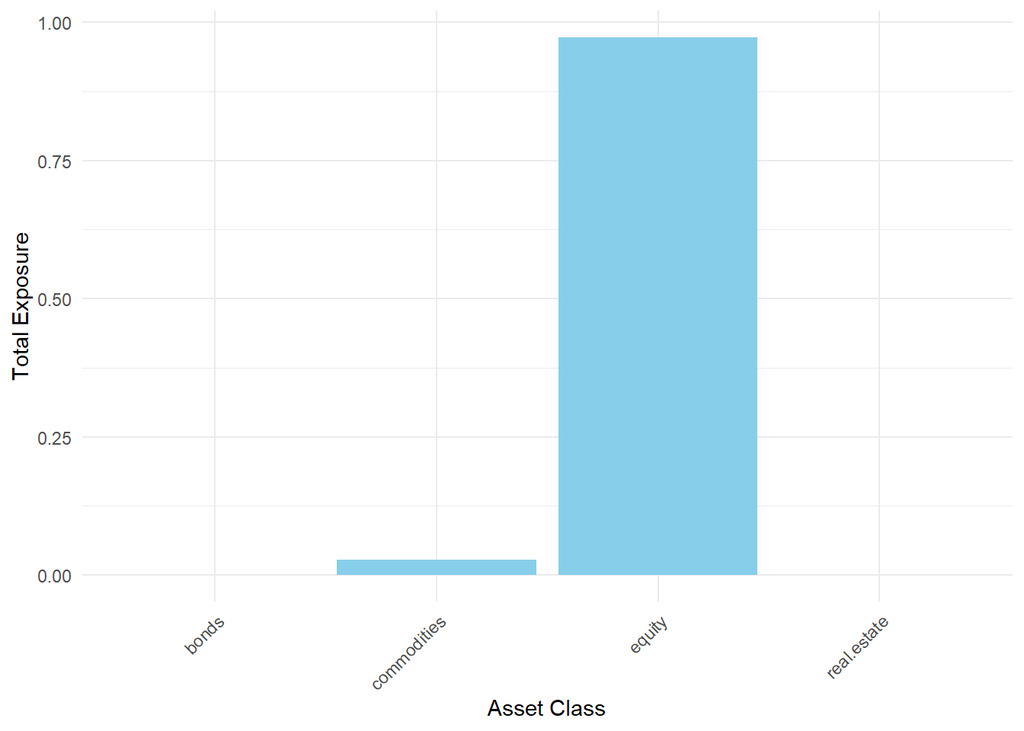

```r
# RW:
EXPOSURE(weights.init = portf.shrink.all, horizon = horizon, y_test = y_test$y_test, asset.classes = asset.classes)
```

```
## $Exposure.ETFs
##                          ETF      Exposure  AssetClass
## 1              S&P 500 TRUST  1.203681e-01      equity
## 2             S&P Midcap 400 -1.206009e-17      equity
## 3               S&P Smallcap  7.971572e-04      equity
## 4                 Technology -2.009320e-18      equity
## 5                 Financials  2.566053e-02      equity
## 6                    Telecom  0.000000e+00      equity
## 7            Basic Materials  0.000000e+00      equity
## 8     Consumer Discretionary  3.673250e-02      equity
## 9           Consumer Staples  2.009497e-01      equity
## 10                    Energy  0.000000e+00      equity
## 11                Healthcare  2.742512e-01      equity
## 12               Industrials  1.508775e-17      equity
## 13                 Utilities  4.655473e-02      equity
```

[output cut: 16 more lines]

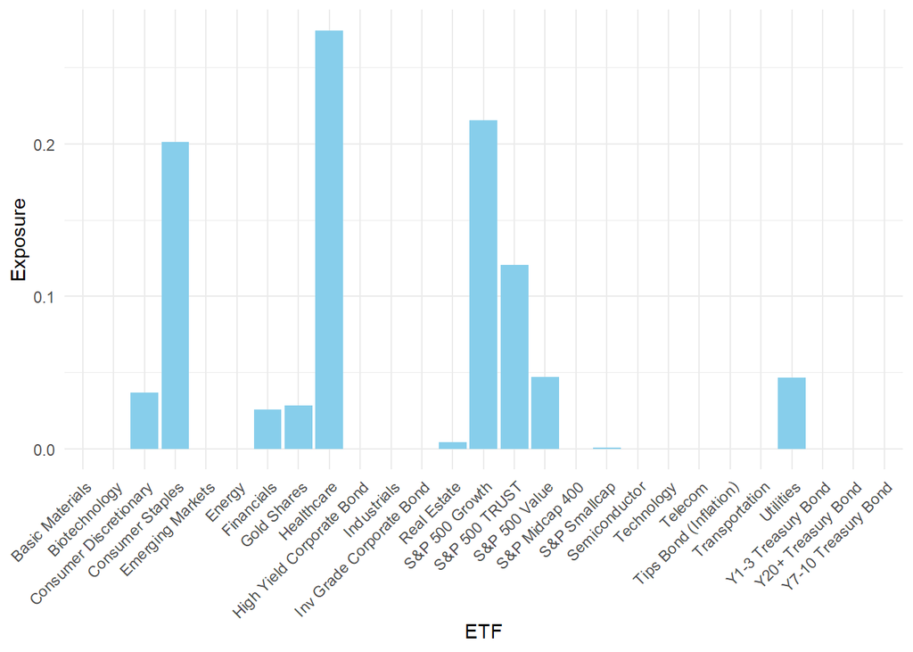

```
##
## $Exposure.asset.classes
## # A tibble: 4 × 2
##   AssetClass  TotalExposure
##   <chr>               <dbl>
## 1 bonds             0
## 2 commodities       0.0281
## 3 equity            0.968
## 4 real.estate       0.00408
##
## $Exposure.asset.classes.plot
```

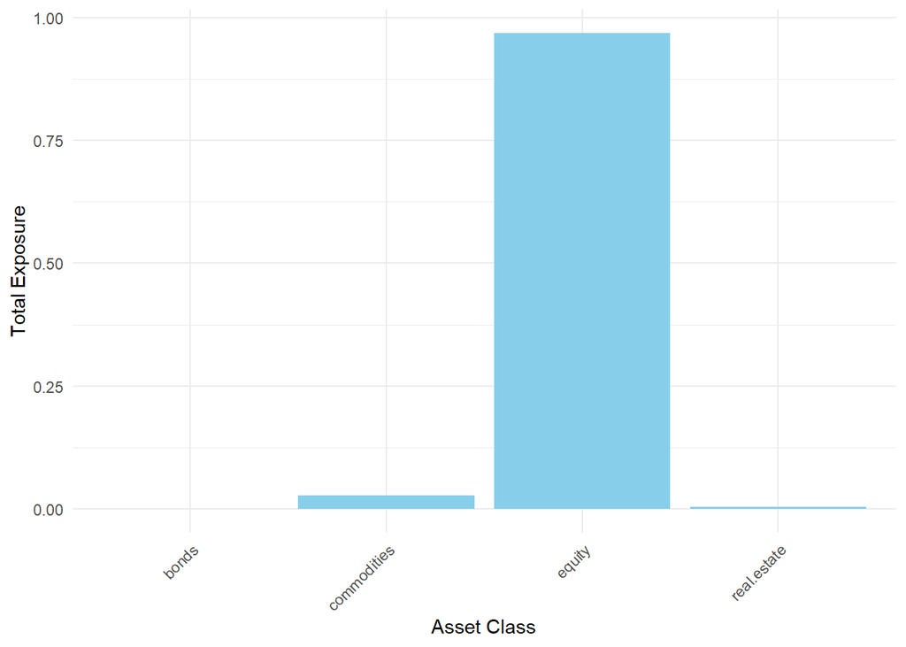

### 3.3.3 Random Forest Method

Next, we are going to test the portfolios which are built upon the return predictions of the Random Forest forecast method. Therefore, we are evaluating both weighting methods (equally and rank weighted) for the long-only and long-short portfolios as well as the minimum variance optimization procedure.

#### 3.3.3.1 Long-Only

```r
# If no Z-Score trans is wished
tmp <- ret
# If Z-score transformation is wished
if(trans.Z == T){
  tmp <- Z.TRANS(ret = ret, Names = Names, last = last)
}
train.rows <- Train.Rows(ret = tmp, train.perc = train.perc)
dates <- index(Test_DS(ret = tmp, train.rows = train.rows, horizon = horizon)$y_test)
y_test <- Test_DS(ret = ret, train.rows = train.rows, horizon = horizon)
counter = 1
t = 1
portf.EW.all <- list()
portf.RW.all <- list()
all.ret.mon.portf.EW <- NULL
all.ret.mon.portf.RW <- NULL
res.RF.L.O <- NULL
cumulative.pred <- as.matrix(cumulative.pred)
colnames(cumulative.pred) <- colnames(mean.ret.cum.all)

## Start the backtest
while(counter < nrow(y_test$y_test[dates,])){

  #print(t)

  res.RF.L.O <- LONG.ONLY(y_test = y_test$y_test[dates,], cum.pred = cumulative.pred, use.long.only = use.long.only,
                          counter = counter, t = t, horizon = horizon, portf.EW.all = portf.EW.all, portf.RW.all = portf.RW.all,
                          all.ret.mon.portf.EW = all.ret.mon.portf.EW, all.ret.mon.portf.RW = all.ret.mon.portf.RW,
                          fix.tc = fix.tc, trans.costs = trans.costs, TER.monthly = TER.monthly, res.all = res.RF.L.O)

  t <- res.RF.L.O$t
  counter <- res.RF.L.O$counter
  # Extract initial weights
  portf.EW.all <- res.RF.L.O$portf.EW.all
  portf.RW.all <- res.RF.L.O$portf.RW.all
  # All other performance results
  all.ret.mon.portf.EW <- res.RF.L.O$ret.portf.EW$`No costs`$`Monthly Portfolio Return`
  all.ret.mon.portf.RW <- res.RF.L.O$ret.portf.RW$`No costs`$`Monthly Portfolio Return`
}

## Summary statistics:
# EW:
stat.EW.LO.RF <- STATISTICS(res = res.RF.L.O$ret.portf.EW, RF = rf, VaR.CI = VaR.CI, horizon = horizon, trans.costs = trans.costs)
# RW:
stat.RW.LO.RF <- STATISTICS(res = res.RF.L.O$ret.portf.RW, RF = rf, VaR.CI = VaR.CI, horizon = horizon, trans.costs = trans.costs)
LO.RF <- list(Equally.Weighted.L.O = stat.EW.LO.RF, Rank.Weighted.L.O = stat.RW.LO.RF)
LO.RF
```

```
## $Equally.Weighted.L.O
##          ret.ann    sd.ann    SR.ann    SR.loss     SortinoR.ann VaR.ann
## no costs 0.09338547 0.1644501 0.4816323 0           0.6522848    0.3420215
## 10bps    0.08843103 0.1645169 0.4513216 -0.06293317 0.6098234    0.3430496
## 20bps    0.08706358 0.16459   0.442813  -0.08059938 0.5980662    0.3430496
## 30bps    0.08569771 0.1646724 0.4342969 -0.09828106 0.5863167    0.3430496
## 40bps    0.0843334  0.1647641 0.4257749 -0.1159751  0.5745768    0.3430496
## 50bps    0.08297067 0.164865  0.4172484 -0.1336785  0.5628485    0.3430496
##          Max.Draw  Turnover.norm
## no costs 0.3036055 0.09838459
## 10bps    0.30644   0.09800682
## 20bps    0.3073329 0.09800688
## 30bps    0.3082258 0.09800694
## 40bps    0.3091187 0.09800701
## 50bps    0.3100115 0.09800707
##
## $Rank.Weighted.L.O
##          ret.ann    sd.ann    SR.ann    SR.loss     SortinoR.ann VaR.ann
## no costs 0.100771   0.1785601 0.4849348 0           0.6513187    0.348053
## 10bps    0.09527886 0.1785986 0.454079  -0.06362886 0.6088293    0.3488864
## 20bps    0.09371956 0.1786481 0.4452249 -0.08188707 0.5969261    0.3488864
## 30bps    0.09216234 0.1787083 0.436361  -0.1001657  0.5850094    0.3488864
## 40bps    0.09060718 0.1787794 0.4274887 -0.1184615  0.5730819    0.3488864
## 50bps    0.08905409 0.1788613 0.4186098 -0.1367709  0.5611464    0.3488864
##          Max.Draw  Turnover.norm
## no costs 0.2978369 0.1115774
## 10bps    0.3010312 0.113767
## 20bps    0.3022153 0.1137655
## 30bps    0.3033993 0.113764
## 40bps    0.3045834 0.1137626
## 50bps    0.3057675 0.1137611
```

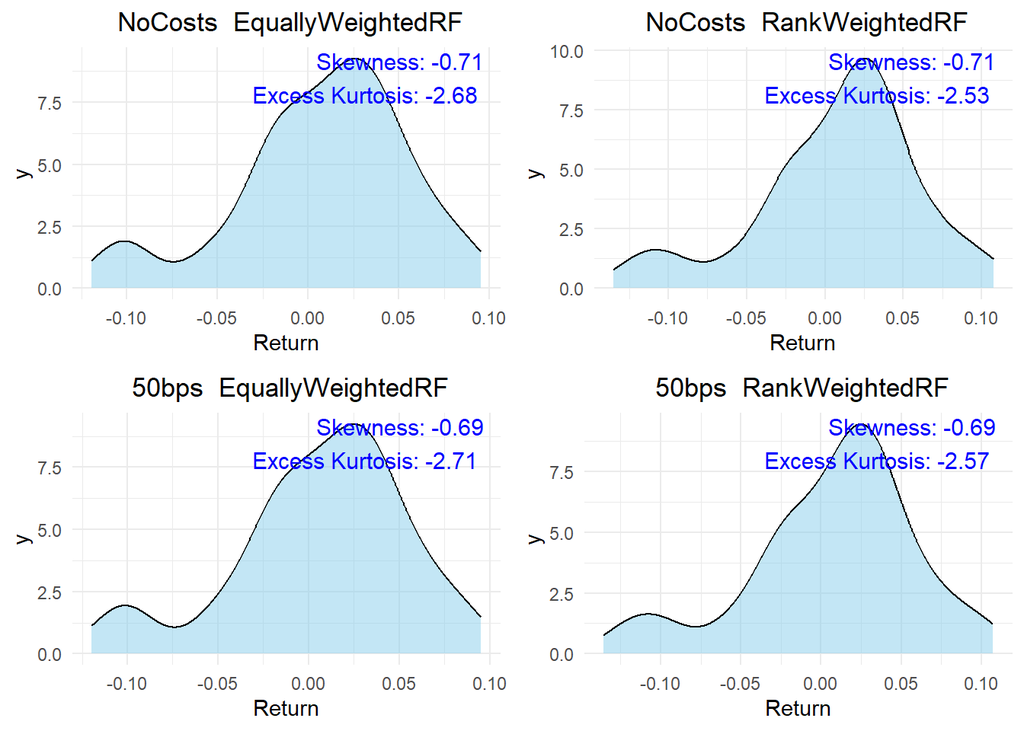

```r
## Distribution of returns:
DISTRIBUTION(res = as.data.frame(do.call(cbind,list(EquallyWeightedRF.NoCosts = res.RF.L.O$ret.portf.EW$`No costs`$`Monthly Portfolio Return`,
                                                    EquallyWeightedRF.50bps = res.RF.L.O$ret.portf.EW$`50bps`$`Monthly Portfolio Return`,
                                                    RankWeightedRF.NoCosts = res.RF.L.O$ret.portf.RW$`No costs`$`Monthly Portfolio Return`,
                                                    RankWeightedRF.50bps = res.RF.L.O$ret.portf.RW$`50bps`$`Monthly Portfolio Return`))))
```

```r
## Positional exposure:
# EW:
EXPOSURE(weights.init = portf.EW.all, horizon = horizon, y_test = y_test$y_test, asset.classes = asset.classes)
```

```
## $Exposure.ETFs
##                          ETF   Exposure  AssetClass
## 1              S&P 500 TRUST 0.01428571      equity
## 2             S&P Midcap 400 0.02857143      equity
## 3               S&P Smallcap 0.07142857      equity
## 4                 Technology 0.14285714      equity
## 5                 Financials 0.04285714      equity
## 6                    Telecom 0.01428571      equity
## 7            Basic Materials 0.01428571      equity
## 8     Consumer Discretionary 0.04285714      equity
## 9           Consumer Staples 0.01428571      equity
## 10                    Energy 0.02857143      equity
## 11                Healthcare 0.07142857      equity
## 12               Industrials 0.01428571      equity
## 13                 Utilities 0.04285714      equity
```

[output cut: 16 more lines]

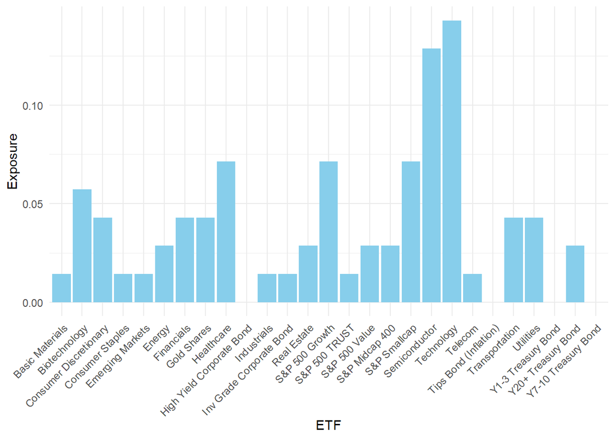

```
##
## $Exposure.asset.classes
## # A tibble: 4 × 2
##   AssetClass  TotalExposure
##   <chr>               <dbl>
## 1 bonds              0.0429
## 2 commodities        0.0429
## 3 equity             0.886
## 4 real.estate        0.0286
##
## $Exposure.asset.classes.plot
```

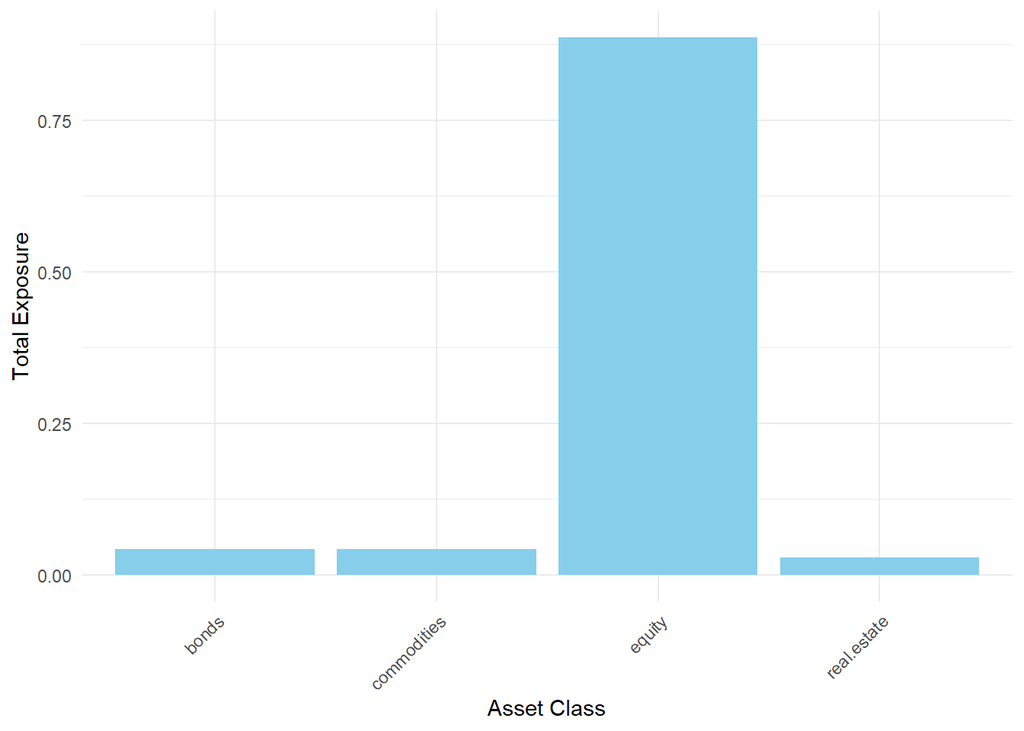

```r
# RW:
EXPOSURE(weights.init = portf.RW.all, horizon = horizon, y_test = y_test$y_test, asset.classes = asset.classes)
```

```
## $Exposure.ETFs
##                          ETF    Exposure  AssetClass
## 1              S&P 500 TRUST 0.007713499      equity
## 2             S&P Midcap 400 0.011019284      equity
## 3               S&P Smallcap 0.047658402      equity
## 4                 Technology 0.162350781      equity
## 5                 Financials 0.021579431      equity
## 6                    Telecom 0.019283747      equity
## 7            Basic Materials 0.019283747      equity
## 8     Consumer Discretionary 0.026997245      equity
## 9           Consumer Staples 0.038567493      equity
## 10                    Energy 0.032139578      equity
## 11                Healthcare 0.058218549      equity
## 12               Industrials 0.007713499      equity
## 13                 Utilities 0.026997245      equity
```

[output cut: 16 more lines]

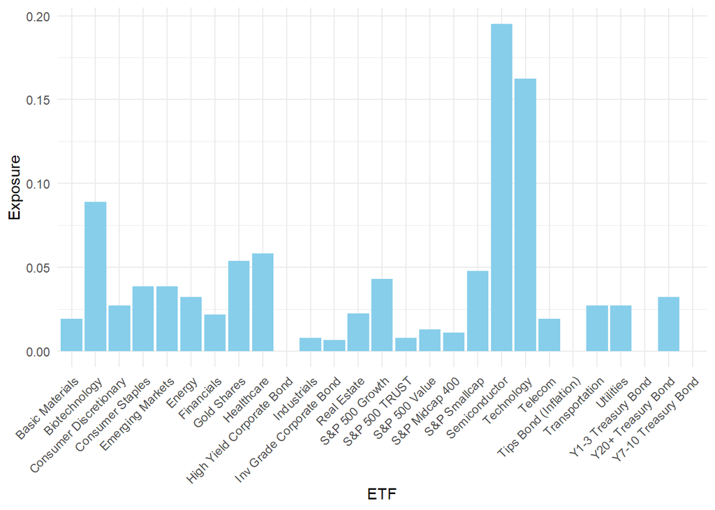

```
##
## $Exposure.asset.classes
## # A tibble: 4 × 2
##   AssetClass  TotalExposure
##   <chr>               <dbl>
## 1 bonds              0.0386
## 2 commodities        0.0537
## 3 equity             0.885
## 4 real.estate        0.0225
##
## $Exposure.asset.classes.plot
```

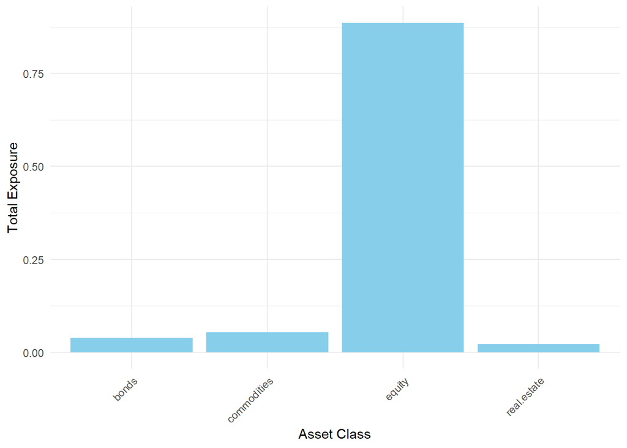

#### 3.3.3.2 Long-Short Portfolio

```r
train.rows <- Train.Rows(ret = ret, train.perc = train.perc)
y_test <- Test_DS(ret = ret, train.rows = train.rows, horizon = horizon)
counter = 1
t = 1
portf.EW.all <- list()
portf.RW.all <- list()
all.ret.mon.portf.EW <- NULL
all.ret.mon.portf.RW <- NULL
res.RF.L.S <- NULL
cumulative.pred <- as.matrix(cumulative.pred)
colnames(cumulative.pred) <- colnames(mean.ret.cum.all)

while(counter < nrow(y_test$y_test)){

  #print(t)

  res.RF.L.S <- LONG.SHORT(y_test = y_test$y_test, cum.pred = cumulative.pred, use.long.short = use.long.short, lend = lend,
                           counter = counter, t = t, horizon = horizon, portf.EW.all = portf.EW.all, portf.RW.all = portf.RW.all,
                           all.ret.mon.portf.EW = all.ret.mon.portf.EW, all.ret.mon.portf.RW = all.ret.mon.portf.RW, fix.tc = fix.tc,
                           trans.costs = trans.costs, TER.monthly = TER.monthly, res.all = res.RF.L.S)

  t <- res.RF.L.S$t
  counter <- res.RF.L.S$counter
  # Extract initial weights
  portf.EW.all <- res.RF.L.S$portf.EW.all
  portf.RW.all <- res.RF.L.S$portf.RW.all
  # All other performance results
  all.ret.mon.portf.EW <- res.RF.L.S$ret.portf.EW$`No costs`$`Monthly Portfolio Return`
  all.ret.mon.portf.RW <- res.RF.L.S$ret.portf.RW$`No costs`$`Monthly Portfolio Return`
}

## Summary statistics:
# EW:
stat.EW.L.S.RF <- STATISTICS(res = res.RF.L.S$ret.portf.EW, RF = rf, VaR.CI = VaR.CI, horizon = horizon, trans.costs = trans.costs)
# RW:
stat.RW.L.S.RF <- STATISTICS(res = res.RF.L.S$ret.portf.RW, RF = rf, VaR.CI = VaR.CI, horizon = horizon, trans.costs = trans.costs)
LS.RF <- list(Equally.Weighted.L.S = stat.EW.L.S.RF, Rank.Weighted.L.S = stat.RW.L.S.RF)
LS.RF
```

```
## $Equally.Weighted.L.S
##          ret.ann     sd.ann     SR.ann      SR.loss   SortinoR.ann VaR.ann
## no costs 0.01437073  0.06446881 0.002943019 0         0.01734889   0.1198564
## 10bps    0.00956981  0.06448222 -0.07151102 -25.29853 -0.07975677  0.1209214
## 20bps    0.008041207 0.06452058 -0.09516023 -33.33422 -0.1101925   0.1209214
## 30bps    0.006514718 0.064594   -0.1186841  -41.32733 -0.1402646   0.1209214
## 40bps    0.004990342 0.06470238 -0.1420451  -49.26511 -0.1699201   0.1209214
## 50bps    0.003468075 0.06484552 -0.1652068  -57.13516 -0.1991109   0.1209214
##          Max.Draw  Turnover.norm
## no costs 0.1814453 0.1229062
## 10bps    0.1903353 0.1226375
## 20bps    0.1928138 0.1226378
## 30bps    0.1952886 0.1226381
## 40bps    0.1977595 0.1226384
## 50bps    0.2002267 0.1226387
##
## $Rank.Weighted.L.S
##          ret.ann     sd.ann     SR.ann      SR.loss   SortinoR.ann VaR.ann
## no costs 0.01703341  0.07060672 0.04039856  0         0.06407212   0.1336769
## 10bps    0.01201699  0.07067912 -0.03061742 -1.757884 -0.02716194  0.1346618
## 20bps    0.0103503   0.07078647 -0.05411621 -2.339558 -0.05704     0.1346618
## 30bps    0.008686157 0.07093143 -0.07746697 -2.917568 -0.08659099  0.1346618
## 40bps    0.007024542 0.07111376 -0.1006339  -3.491028 -0.1157683   0.1360555
## 50bps    0.005365457 0.07133317 -0.1235827  -4.059086 -0.1445288   0.1401179
##          Max.Draw  Turnover.norm
## no costs 0.2011574 0.1331674
## 10bps    0.2094671 0.1350462
## 20bps    0.2122865 0.1350453
## 30bps    0.2151008 0.1350444
## 40bps    0.2179102 0.1350434
## 50bps    0.2207144 0.1350425
```

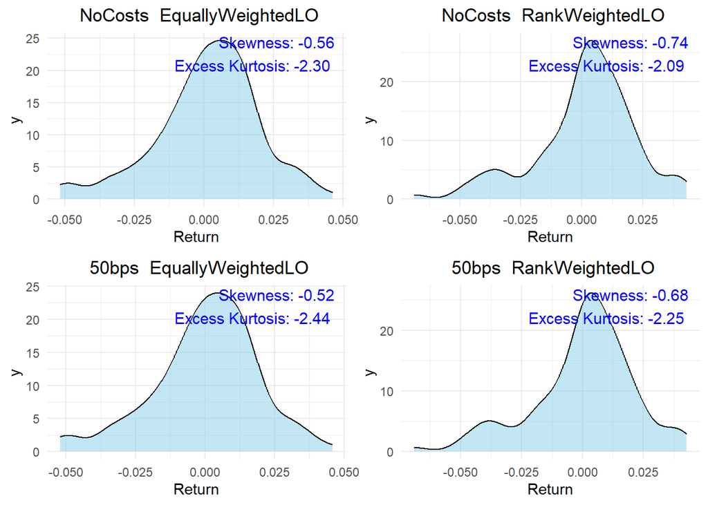

```r
## Distribution of returns:
# ATTENTION: THE NAMING OF THE VECTORS IS ESSENTIAL AND HAS TO FOLLOW THE SEQUENCE "WEIGHTINGTYPE.COSTS"
DISTRIBUTION(res = as.data.frame(do.call(cbind,list(EquallyWeightedLO.NoCosts = res.RF.L.S$ret.portf.EW$`No costs`$`Monthly Portfolio Return`,
                                                    EquallyWeightedLO.50bps = res.RF.L.S$ret.portf.EW$`50bps`$`Monthly Portfolio Return`,
                                                    RankWeightedLO.NoCosts = res.RF.L.S$ret.portf.RW$`No costs`$`Monthly Portfolio Return`,
                                                    RankWeightedLO.50bps = res.RF.L.S$ret.portf.RW$`50bps`$`Monthly Portfolio Return`))))
```

```r
## Positional exposure:
# EW:
EXPOSURE(weights.init = portf.EW.all, horizon = horizon, y_test = y_test$y_test, asset.classes = asset.classes)
```

```
## $Exposure.ETFs
##                          ETF     Exposure  AssetClass
## 1              S&P 500 TRUST  0.007142857      equity
## 2             S&P Midcap 400  0.000000000      equity
## 3               S&P Smallcap  0.021428571      equity
## 4                 Technology  0.071428571      equity
## 5                 Financials  0.007142857      equity
## 6                    Telecom -0.028571429      equity
## 7            Basic Materials -0.007142857      equity
## 8     Consumer Discretionary  0.021428571      equity
## 9           Consumer Staples  0.000000000      equity
## 10                    Energy -0.028571429      equity
## 11                Healthcare  0.035714286      equity
## 12               Industrials  0.000000000      equity
## 13                 Utilities  0.007142857      equity
```

[output cut: 16 more lines]

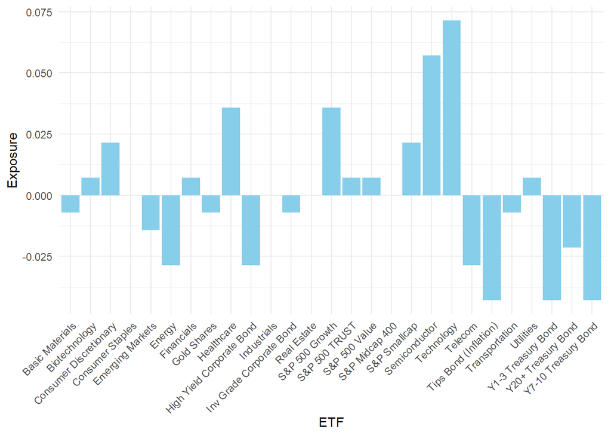

```
##
## $Exposure.asset.classes
## # A tibble: 4 × 2
##   AssetClass  TotalExposure
##   <chr>               <dbl>
## 1 bonds            -0.186
## 2 commodities      -0.00714
## 3 equity            0.193
## 4 real.estate       0
##
## $Exposure.asset.classes.plot
```

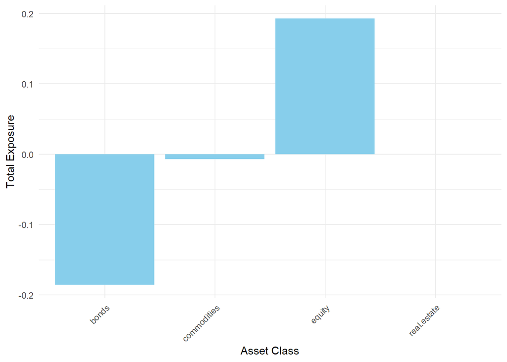

```r
# RW:
EXPOSURE(weights.init = portf.RW.all, horizon = horizon, y_test = y_test$y_test, asset.classes = asset.classes)
```

```
## $Exposure.ETFs
##                          ETF      Exposure  AssetClass
## 1              S&P 500 TRUST  0.0038567493      equity
## 2             S&P Midcap 400 -0.0047750230      equity
## 3               S&P Smallcap  0.0178604224      equity
## 4                 Technology  0.0811753903      equity
## 5                 Financials -0.0036730946      equity
## 6                    Telecom -0.0337465565      equity
## 7            Basic Materials  0.0009641873      equity
## 8     Consumer Discretionary  0.0134986226      equity
## 9           Consumer Staples  0.0000000000      equity
## 10                    Energy -0.0024793388      equity
## 11                Healthcare  0.0291092746      equity
## 12               Industrials -0.0154269972      equity
## 13                 Utilities  0.0038567493      equity
```

[output cut: 16 more lines]

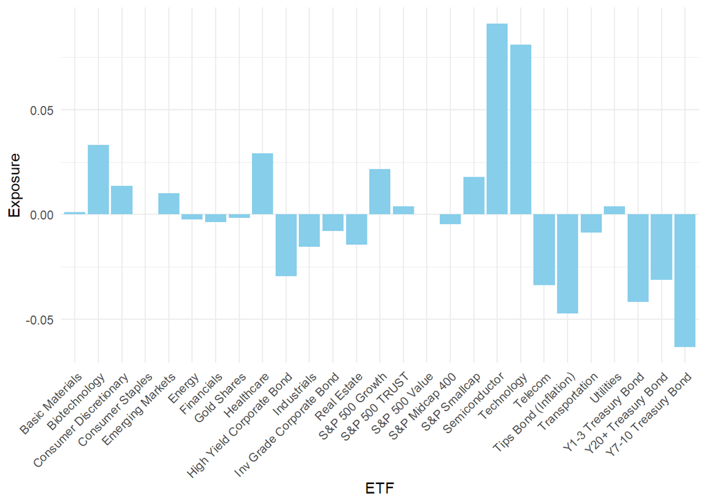

```
##
## $Exposure.asset.classes
## # A tibble: 4 × 2
##   AssetClass  TotalExposure
##   <chr>               <dbl>
## 1 bonds            -0.221
## 2 commodities      -0.00179
## 3 equity            0.237
## 4 real.estate      -0.0145
##
## $Exposure.asset.classes.plot
```

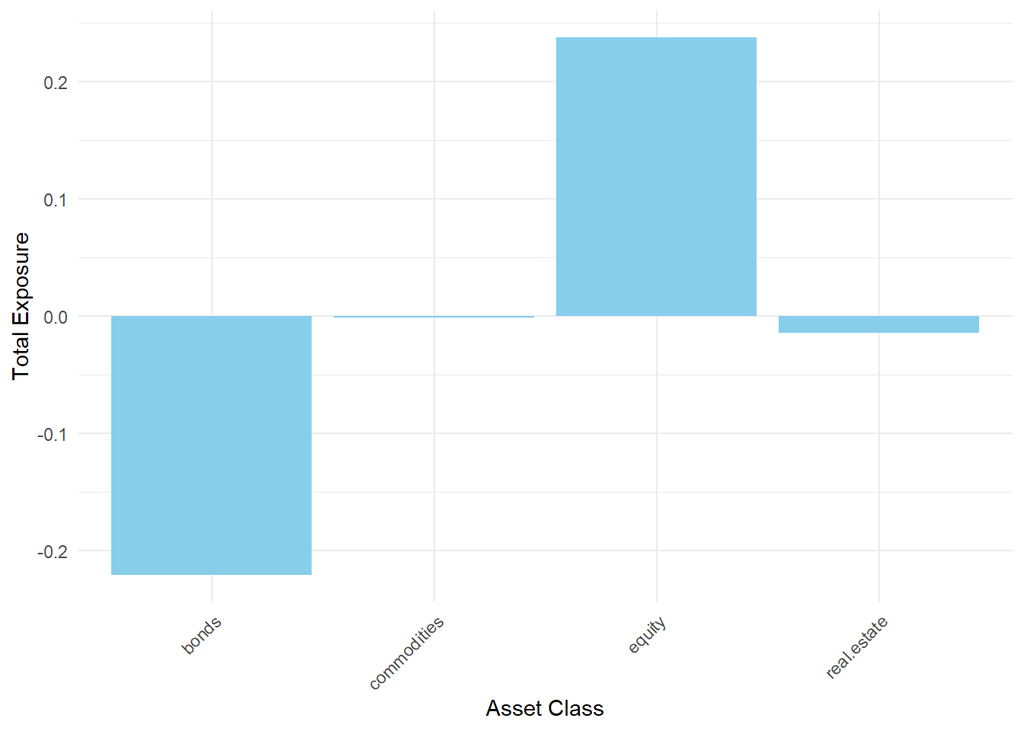

#### 3.3.3.3 Minimum Variance

```r
train.rows <- Train.Rows(ret = ret, train.perc = train.perc)
y_test <- Test_DS(ret = ret, train.rows = train.rows, horizon = horizon)
counter = 1
t = 1
portf.sample.all <- list()
portf.shrink.all <- list()
all.ret.mon.portf.sample <- NULL
all.ret.mon.portf.shrink <- NULL
res.MV.RF <- NULL
cumulative.pred <- as.matrix(cumulative.pred)
colnames(cumulative.pred) <- colnames(mean.ret.cum.all)

while(counter < nrow(y_test$y_test)){

  #print(t)

  res.MV.RF <- MIN.VAR(ret = ret, train.rows = train.rows, y_test = y_test$y_test, cum.pred = cumulative.pred,
                       use.minvar = use.minvar, counter = counter, t = t, horizon = horizon,
                       portf.shrink.all = portf.shrink.all, portf.sample.all = portf.sample.all,
                       trans.costs = trans.costs, TER.monthly = TER.monthly, all.ret.mon.portf.shrink = all.ret.mon.portf.shrink,
                       all.ret.mon.portf.sample = all.ret.mon.portf.sample, limit = limit, fix.tc = fix.tc, min.max = min.max,
                       res.all = res.MV.RF)

  train.rows <- res.MV.RF$train.rows
  t <- res.MV.RF$t
  counter <- res.MV.RF$counter
  # Extract initial weights
  portf.sample.all <- res.MV.RF$portf.sample.all
  portf.shrink.all <- res.MV.RF$portf.shrink.all
  # All other performance results
  all.ret.mon.portf.sample<- res.MV.RF$ret.portf.sample$`No costs`$`Monthly Portfolio Return`
  all.ret.mon.portf.shrink <- res.MV.RF$ret.portf.shrink$`No costs`$`Monthly Portfolio Return`
}

## Summary statistics:
# EW:
stat.MV.sample.RF <- STATISTICS(res = res.MV.RF$ret.portf.sample, RF = rf, VaR.CI = VaR.CI, horizon = horizon, trans.costs = trans.costs)
# RW:
stat.MV.shrink.RF <- STATISTICS(res = res.MV.RF$ret.portf.shrink, RF = rf, VaR.CI = VaR.CI, horizon = horizon, trans.costs = trans.costs)
MV.RF <- list(sample.MV = stat.MV.sample.RF, shrink.MV = stat.MV.shrink.RF)
MV.RF
```

```
## $sample.MV
##          ret.ann    sd.ann    SR.ann    SR.loss     SortinoR.ann VaR.ann
## no costs 0.08307013 0.139529  0.4937263 0           0.6785602    0.2785667
## 10bps    0.07845674 0.1395795 0.4604956 -0.06730581 0.6311718    0.2796625
## 20bps    0.07675112 0.1396343 0.4480999 -0.09241231 0.6138496    0.2796625
## 30bps    0.07504798 0.1397083 0.4356718 -0.1175844  0.596523     0.2796625
## 40bps    0.07334734 0.1398016 0.4232166 -0.1428113  0.5791789    0.2807396
## 50bps    0.07164918 0.1399139 0.4107395 -0.1680826  0.5618222    0.2821768
##          Max.Draw  Turnover.norm
## no costs 0.2293512 0.1273905
## 10bps    0.2369527 0.1283901
## 20bps    0.2397563 0.1283892
## 30bps    0.242555  0.1283883
## 40bps    0.2453486 0.1283874
## 50bps    0.2481372 0.1283865
##
## $shrink.MV
##          ret.ann    sd.ann    SR.ann    SR.loss     SortinoR.ann VaR.ann
## no costs 0.08289814 0.1408312 0.4879398 0           0.6726381    0.2703038
## 10bps    0.07816539 0.1408902 0.4541437 -0.06926292 0.6242437    0.2712795
## 20bps    0.07641131 0.1409521 0.4414997 -0.09517579 0.6064523    0.2716658
## 30bps    0.07465988 0.1410329 0.4288282 -0.1211452  0.5886702    0.2737322
## 40bps    0.0729111  0.1411326 0.4161343 -0.1471606  0.5709029    0.2757987
## 50bps    0.07116496 0.1412511 0.4034232 -0.1732111  0.5531425    0.2778651
##          Max.Draw  Turnover.norm
## no costs 0.2273573 0.1310904
## 10bps    0.2350095 0.1326395
## 20bps    0.2377938 0.132638
## 30bps    0.240573  0.1326365
## 40bps    0.2433473 0.1326349
## 50bps    0.2461166 0.1326334
```

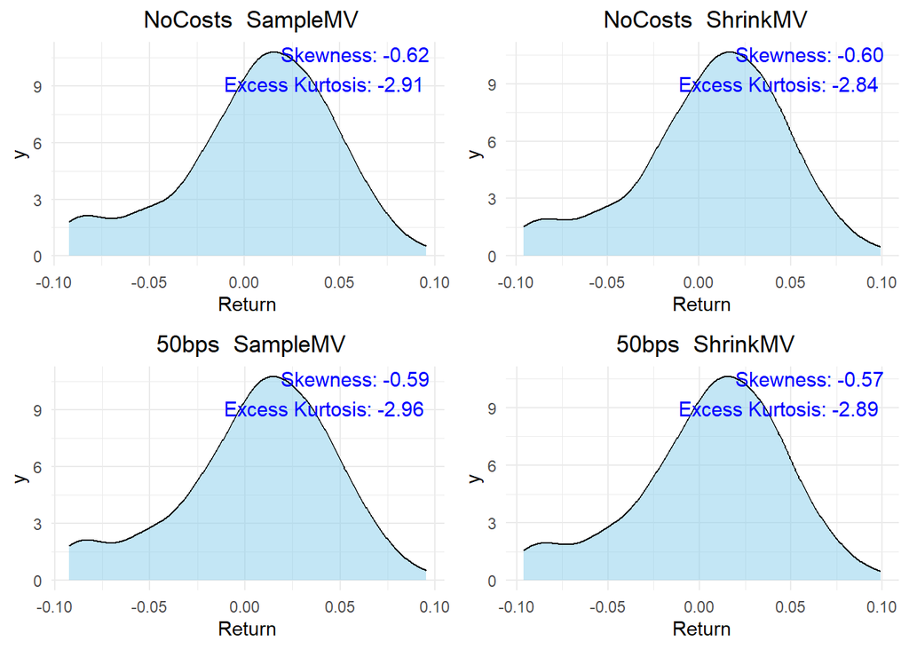

```r
## Distribution of returns:
# ATTENTION: THE NAMING OF THE VECTORS IS ESSENTIAL AND HAS TO FOLLOW THE SEQUENCE "WEIGHTINGTYPE.COSTS"
DISTRIBUTION(res = as.data.frame(do.call(cbind,list(SampleMV.NoCosts = res.MV.RF$ret.portf.sample$`No costs`$`Monthly Portfolio Return`,
                                                    SampleMV.50bps = res.MV.RF$ret.portf.sample$`50bps`$`Monthly Portfolio Return`,
                                                    ShrinkMV.NoCosts = res.MV.RF$ret.portf.shrink$`No costs`$`Monthly Portfolio Return`,
                                                    ShrinkMV.50bps = res.MV.RF$ret.portf.shrink$`50bps`$`Monthly Portfolio Return`))))
```

```r
## Positional exposure:
# EW:
EXPOSURE(weights.init = portf.sample.all, horizon = horizon, y_test = y_test$y_test, asset.classes = asset.classes)
```

```
## $Exposure.ETFs
##                          ETF      Exposure  AssetClass
## 1              S&P 500 TRUST  8.802586e-03      equity
## 2             S&P Midcap 400  0.000000e+00      equity
## 3               S&P Smallcap  2.689492e-17      equity
## 4                 Technology  5.267309e-02      equity
## 5                 Financials  1.271570e-02      equity
## 6                    Telecom  1.109218e-02      equity
## 7            Basic Materials -4.830309e-19      equity
## 8     Consumer Discretionary  1.033654e-02      equity
## 9           Consumer Staples  2.706279e-02      equity
## 10                    Energy  2.220167e-18      equity
## 11                Healthcare  2.675995e-01      equity
## 12               Industrials  0.000000e+00      equity
## 13                 Utilities  4.977691e-02      equity
```

[output cut: 16 more lines]

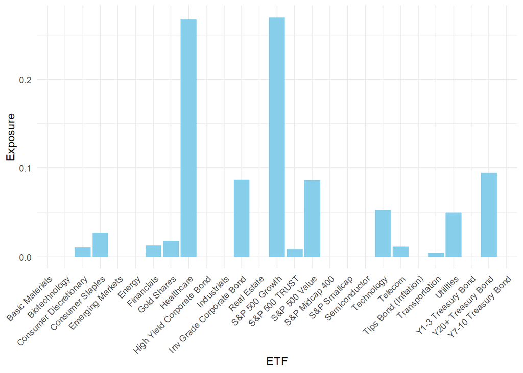

```
##
## $Exposure.asset.classes
## # A tibble: 4 × 2
##   AssetClass  TotalExposure
##   <chr>               <dbl>
## 1 bonds            1.81e- 1
## 2 commodities      1.80e- 2
## 3 equity           8.01e- 1
## 4 real.estate     -5.76e-18
##
## $Exposure.asset.classes.plot
```

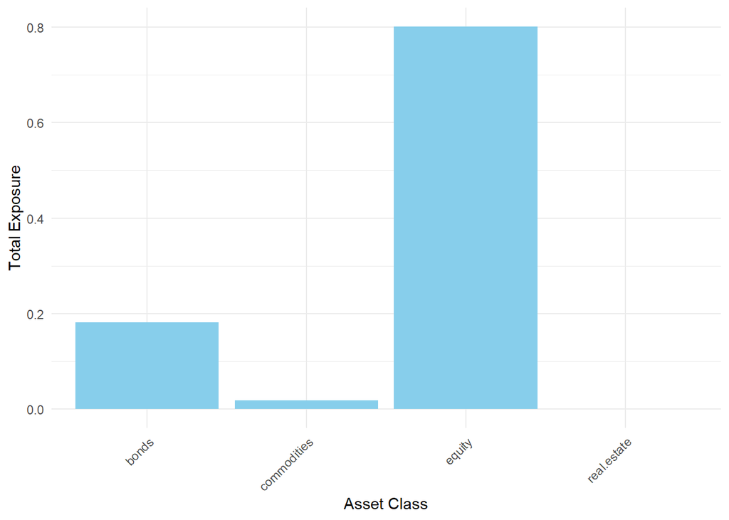

```r
# RW:
EXPOSURE(weights.init = portf.shrink.all, horizon = horizon, y_test = y_test$y_test, asset.classes = asset.classes)
```

```
## $Exposure.ETFs
##                          ETF      Exposure  AssetClass
## 1              S&P 500 TRUST  2.259720e-02      equity
## 2             S&P Midcap 400  4.576281e-03      equity
## 3               S&P Smallcap  1.869562e-03      equity
## 4                 Technology  6.650459e-02      equity
## 5                 Financials  1.959331e-02      equity
## 6                    Telecom  1.177731e-02      equity
## 7            Basic Materials  1.167290e-18      equity
## 8     Consumer Discretionary  2.915577e-02      equity
## 9           Consumer Staples  2.878391e-02      equity
## 10                    Energy  3.252397e-18      equity
## 11                Healthcare  2.403137e-01      equity
## 12               Industrials  0.000000e+00      equity
## 13                 Utilities  5.357448e-02      equity
```

[output cut: 16 more lines]

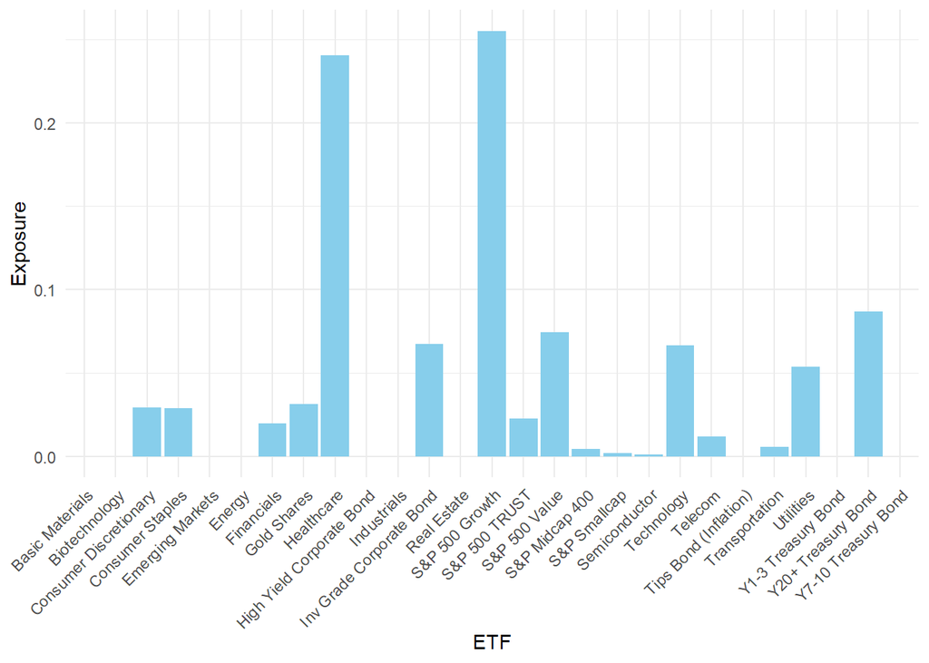

```
##
## $Exposure.asset.classes
## # A tibble: 4 × 2
##   AssetClass  TotalExposure
##   <chr>               <dbl>
## 1 bonds            1.54e- 1
## 2 commodities      3.14e- 2
## 3 equity           8.15e- 1
## 4 real.estate     -6.54e-19
##
## $Exposure.asset.classes.plot
```

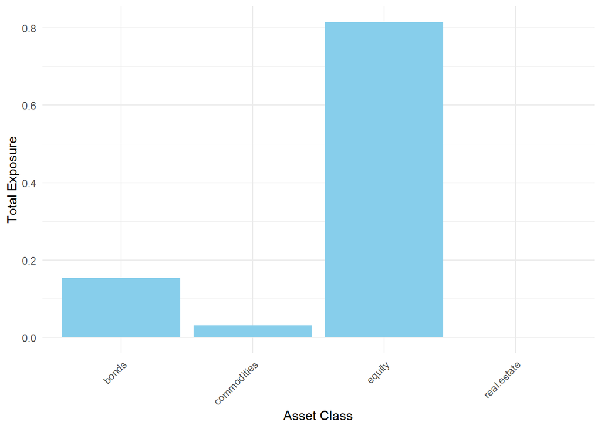

### 3.3.4 Minimum Variance Raw

Means, only long-only weight constraint is imposed and all available ETFs are used in all portfolios.

```r
train.rows <- Train.Rows(ret = ret, train.perc = train.perc)
y_test <- Test_DS(ret = ret, train.rows = train.rows, horizon = horizon)
counter = 1
t = 1
portf.sample.all <- list()
portf.shrink.all <- list()
all.ret.mon.portf.sample <- NULL
all.ret.mon.portf.shrink <- NULL
res.MV.raw <- NULL
use.minvar = 1 # Use all ETFs
min.max = c(0,1)

while(counter < nrow(y_test$y_test)){

  #print(t)

  res.MV.raw <- MIN.VAR(ret = ret, train.rows = train.rows, y_test = y_test$y_test, cum.pred = mean.ret.cum.all,
                        use.minvar = use.minvar,counter = counter, t = t, horizon = horizon,
                        portf.shrink.all = portf.shrink.all, portf.sample.all = portf.sample.all,
                        trans.costs = trans.costs, TER.monthly = TER.monthly, all.ret.mon.portf.shrink = all.ret.mon.portf.shrink,
                        all.ret.mon.portf.sample = all.ret.mon.portf.sample, limit = limit, fix.tc = fix.tc,
                        min.max = min.max, res.all = res.MV.raw)

  train.rows <- res.MV.raw$train.rows
  t <- res.MV.raw$t
  counter <- res.MV.raw$counter
  # Extract initial weights
  portf.sample.all <- res.MV.raw$portf.sample.all
  portf.shrink.all <- res.MV.raw$portf.shrink.all
  # All other performance results
  all.ret.mon.portf.sample<- res.MV.raw$ret.portf.sample$`No costs`$`Monthly Portfolio Return`
  all.ret.mon.portf.shrink <- res.MV.raw$ret.portf.shrink$`No costs`$`Monthly Portfolio Return`
}

## Summary statistics:
# EW:
stat.MV.sample <- STATISTICS(res = res.MV.raw$ret.portf.sample, RF = rf, VaR.CI = VaR.CI, horizon = horizon, trans.costs = trans.costs)
# RW:
stat.MV.shrink <- STATISTICS(res = res.MV.raw$ret.portf.shrink, RF = rf, VaR.CI = VaR.CI, horizon = horizon, trans.costs = trans.costs)
list(sample.MV = stat.MV.sample, shrink.MV = stat.MV.shrink)
```

```
## $sample.MV
##          ret.ann     sd.ann     SR.ann     SR.loss   SortinoR.ann VaR.ann
## no costs 0.01201327  0.01500448 -0.1444723 0         -0.1285086   0.02555659
## 10bps    0.01002898  0.01500324 -0.2767412 0.9155305 -0.2915455   0.02629546
## 20bps    0.009620358 0.01501696 -0.3036994 1.102128  -0.3245114   0.02658102
## 30bps    0.009211874 0.01504622 -0.3302574 1.285956  -0.3569624   0.02659082
## 40bps    0.008803527 0.01509093 -0.3563381 1.46648   -0.3885451   0.02659082
## 50bps    0.008395317 0.01515095 -0.3818694 1.643201  -0.4191252   0.02659082
##          Max.Draw   Turnover.norm
## no costs 0.05613484 0.002629326
## 10bps    0.05856804 0.002161989
## 20bps    0.05914671 0.00216237
## 30bps    0.05972521 0.002162753
## 40bps    0.06030353 0.002163283
## 50bps    0.06088167 0.002163879
##
## $shrink.MV
##          ret.ann    sd.ann     SR.ann       SR.loss    SortinoR.ann  VaR.ann
## no costs 0.01769662 0.03284683 0.1070308    0          0.168041      0.05639018
## 10bps    0.01522957 0.03284647 0.03192348   -0.7017356 0.06793767    0.05697628
## 20bps    0.01465239 0.03285521 0.01434747   -0.8659501 0.04485909    0.05697628
## 30bps    0.01407553 0.03287473 -0.003208148 -1.029974  0.02192005    0.05697628
## 40bps    0.01349901 0.03290499 -0.02072618  -1.193647  -0.0008668377 0.05697628
## 50bps    0.01292281 0.03294597 -0.03818963  -1.35681   -0.02348794   0.05697628
##          Max.Draw  Turnover.norm
## no costs 0.1065918 0.01769097
## 10bps    0.1089943 0.01745433
## 20bps    0.1097477 0.01745306
## 30bps    0.1105358 0.01745179
## 40bps    0.1113235 0.01745052
## 50bps    0.1121108 0.01744925
```

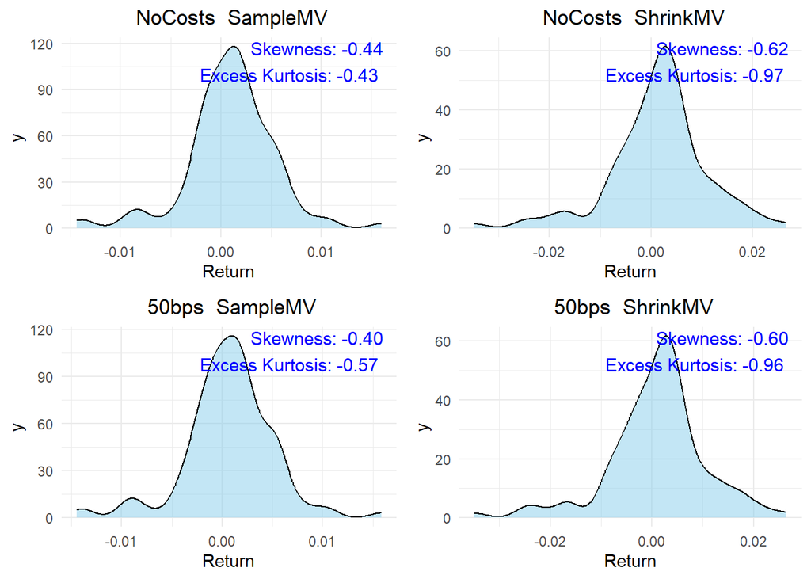

```r
## Distribution of returns:
# ATTENTION: THE NAMING OF THE VECTORS IS ESSENTIAL AND HAS TO FOLLOW THE SEQUENCE "WEIGHTINGTYPE.COSTS"
DISTRIBUTION(res = as.data.frame(do.call(cbind,list(SampleMV.NoCosts = res.MV.raw$ret.portf.sample$`No costs`$`Monthly Portfolio Return`,
                                                    SampleMV.50bps = res.MV.raw$ret.portf.sample$`50bps`$`Monthly Portfolio Return`,
                                                    ShrinkMV.NoCosts = res.MV.raw$ret.portf.shrink$`No costs`$`Monthly Portfolio Return`,
                                                    ShrinkMV.50bps = res.MV.raw$ret.portf.shrink$`50bps`$`Monthly Portfolio Return`))))
```

```r
## Positional exposure:
# EW:
EXPOSURE(weights.init = portf.sample.all, horizon = horizon, y_test = y_test$y_test, asset.classes = asset.classes)
```

```
## $Exposure.ETFs
##                          ETF      Exposure  AssetClass
## 1              S&P 500 TRUST  1.211343e-16      equity
## 2             S&P Midcap 400 -2.278329e-18      equity
## 3               S&P Smallcap  4.759295e-04      equity
## 4                 Technology  1.343827e-03      equity
## 5                 Financials  1.256323e-02      equity
## 6                    Telecom  2.997586e-03      equity
## 7            Basic Materials  1.298084e-18      equity
## 8     Consumer Discretionary -3.170845e-19      equity
## 9           Consumer Staples  3.382291e-04      equity
## 10                    Energy  2.977988e-03      equity
## 11                Healthcare -1.665709e-18      equity
## 12               Industrials  3.355126e-18      equity
## 13                 Utilities -1.353344e-18      equity
```

[output cut: 16 more lines]

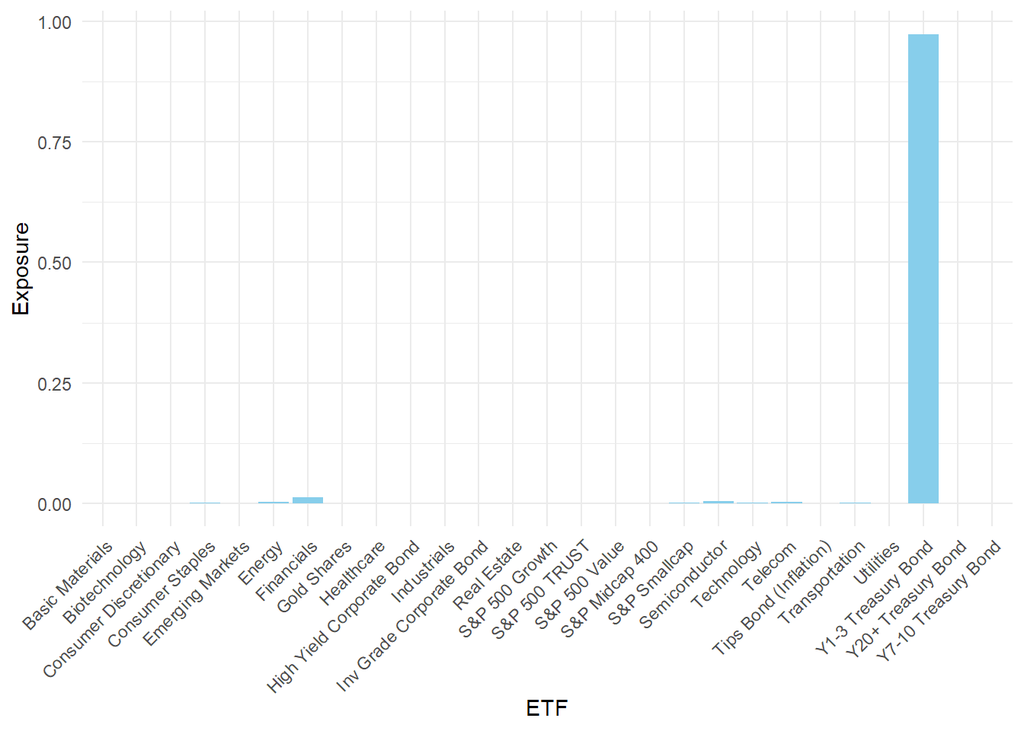

```
##
## $Exposure.asset.classes
## # A tibble: 4 × 2
##   AssetClass  TotalExposure
##   <chr>               <dbl>
## 1 bonds            9.74e- 1
## 2 commodities      5.91e-19
## 3 equity           2.61e- 2
## 4 real.estate     -4.25e-18
##
## $Exposure.asset.classes.plot
```

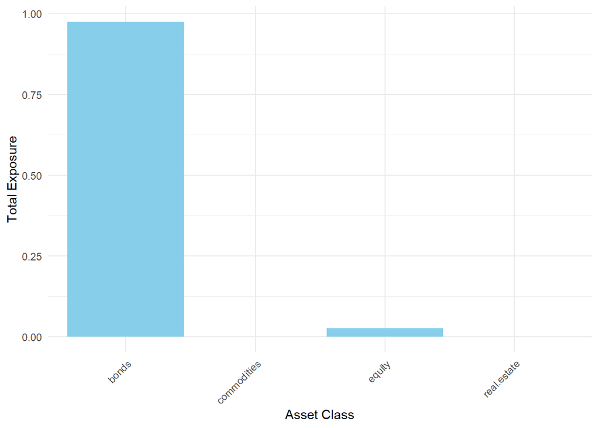

```r
# RW:
EXPOSURE(weights.init = portf.shrink.all, horizon = horizon, y_test = y_test$y_test, asset.classes = asset.classes)
```

```
## $Exposure.ETFs
##                          ETF      Exposure  AssetClass
## 1              S&P 500 TRUST -5.327288e-19      equity
## 2             S&P Midcap 400 -5.507233e-18      equity
## 3               S&P Smallcap  1.651101e-03      equity
## 4                 Technology  6.828388e-03      equity
## 5                 Financials  2.499453e-02      equity
## 6                    Telecom  1.867131e-03      equity
## 7            Basic Materials -5.222699e-18      equity
## 8     Consumer Discretionary  1.310468e-04      equity
## 9           Consumer Staples  7.740894e-03      equity
## 10                    Energy  3.523228e-03      equity
## 11                Healthcare  2.825093e-03      equity
## 12               Industrials  1.584993e-17      equity
## 13                 Utilities  1.523312e-03      equity
```

[output cut: 16 more lines]

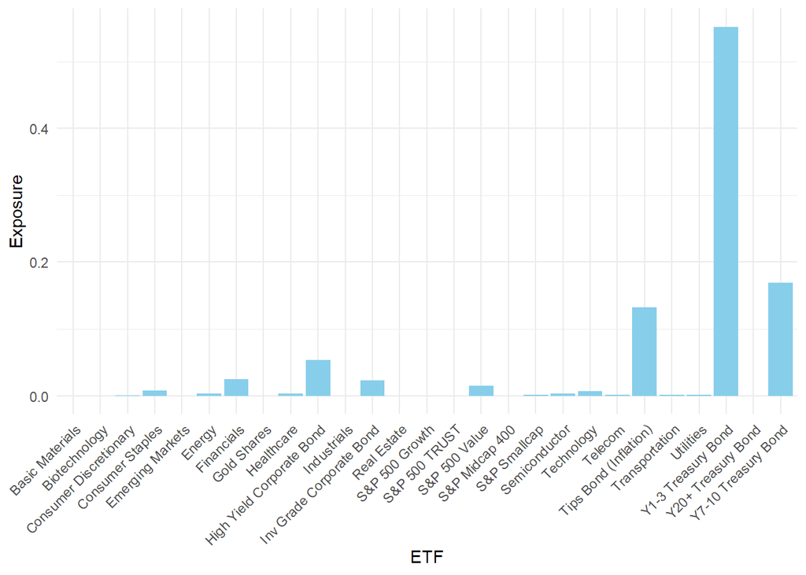

```
##
## $Exposure.asset.classes
## # A tibble: 4 × 2
##   AssetClass  TotalExposure
##   <chr>               <dbl>
## 1 bonds            9.30e- 1
## 2 commodities     -1.64e-19
## 3 equity           7.03e- 2
## 4 real.estate      7.03e-19
##
## $Exposure.asset.classes.plot
```

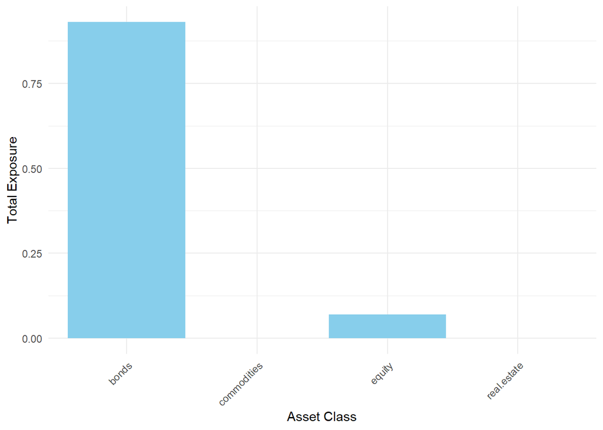

## 3.4 Wealth Development Simulation

In this subsection we further evaluate the performance of the portfolio strategies by analyzing the wealth development of the methods. Since the differences between the transaction costs scenarios are not that significant we are only going to compare the “no costs” scenario with the “50bps” scenario.

### 3.4.1 Benchmarks

#### 3.4.1.1 Buy-and-Hold MSCI World

e start by executing the wealth simulation.

```r
BAH.noCost <- WEALTH.SIMULATION(ret = res.bench$`no costs`$ret.noCosts, init = init)
BAH.50bps <- WEALTH.SIMULATION(ret = res.bench$`50bps`$ret.Costs, init = init)
```

Next, we plot the no cost scenario versus the 50bps TC scenario. Therefore, we first need to extract the out-of-sample dates.

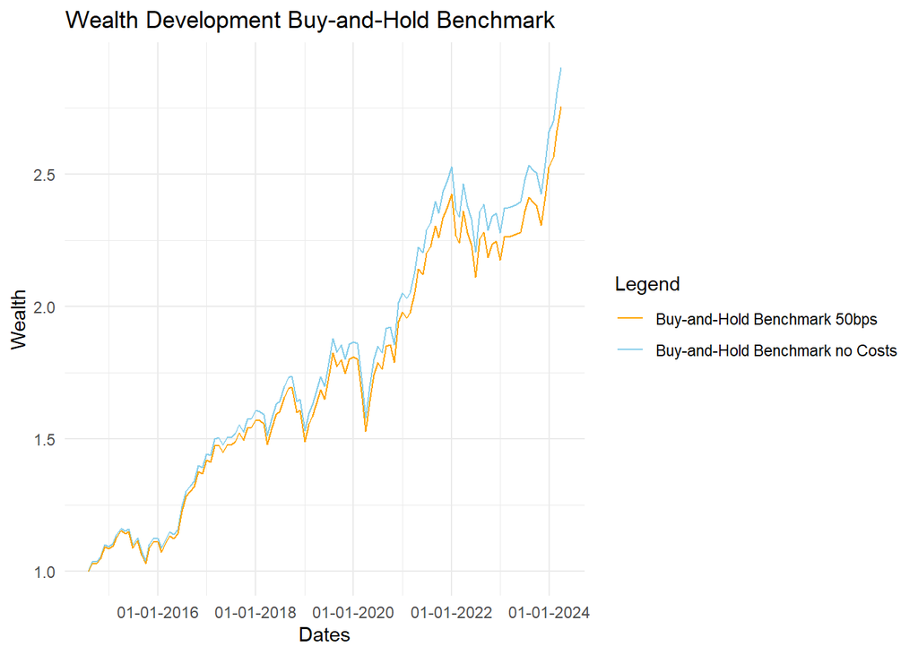

```r
# Extract out-of-sample dates
date <- index(BAH.noCost$Wealth)

# Representation of EW and RW strategy each with noCost and 50bps scenario in one plot
ggplot(BAH.noCost$Wealth) +
  geom_line(aes(x=date, y = Wealth, color = "Buy-and-Hold Benchmark no Costs")) +
  geom_line(aes(x=date, y = BAH.50bps$Wealth, color = "Buy-and-Hold Benchmark 50bps")) +
  scale_x_date(labels = date_format("%d-%m-%Y")) +
  scale_color_manual("Legend", values = c("Buy-and-Hold Benchmark no Costs" = "skyblue", "Buy-and-Hold Benchmark 50bps" = "orange")) +
  labs(title = "Wealth Development Buy-and-Hold Benchmark", x = "Dates", y = "Wealth") +
  theme_minimal()
```

Now let’s have a look at the Maximum Drawdowns.

```r
# Show Maximum Drawdowns
rbind(BAHBenchmark.noCosts = BAH.noCost$maxDraw, BAHBenchmark.50bps = BAH.50bps$maxDraw)
```

```
##                            From     Trough         To   Depth
## BAHBenchmark.noCosts 2019-08-30 2020-03-31 2020-08-31 -0.1603
## BAHBenchmark.50bps   2019-08-30 2020-03-31 2020-08-31 -0.1632
```

Last but not least, let’s compare the absolute and relative returns for the given scenarios

```r
# Display absolute and relative returns in a table:
returns.BAHBench.Wealth <- list(BAH.abs.noCost = BAH.noCost$abs.ret,
                                  BAH.abs.50bps = BAH.50bps$abs.ret,
                                  BAH.rel.noCost = BAH.noCost$rel.ret,
                                  BAH.rel.50bps = BAH.50bps$rel.ret)

returns.BAHBench.Wealth <- bind_rows(lapply(names(returns.BAHBench.Wealth), function(name){
  data_frame <- data.frame(value = returns.BAHBench.Wealth[[name]])
  data_frame$Type <- name  # Add the list name as a new column
  return(data_frame)
}))

returns.BAHBench.Wealth <- returns.BAHBench.Wealth %>%
    mutate(
      Strategy = ifelse(grepl("^BAH", Type), "Buy-and-Hold"),
      Return_Type = ifelse(grepl("rel", Type), "rel", "abs"),
      Cost = ifelse(grepl("noCost", Type), "noCost", "50bps")
      ) %>%
  select(-Type)

# Reshape the data to a wide format table
returns.BAHBench.Wealth <- returns.BAHBench.Wealth %>%
  pivot_wider(names_from = Return_Type, values_from = value) %>%
  arrange(Strategy, Cost)

returns.BAHBench.Wealth
```

```
## # A tibble: 2 × 4
##   Strategy     Cost     abs   rel
##   <chr>        <chr>  <dbl> <dbl>
## 1 Buy-and-Hold 50bps   1.76  1.76
## 2 Buy-and-Hold noCost  1.90  1.90
```

#### 3.4.1.2 50-50 MSCI World & 20Y+ US Gov Bond

We start by executing the wealth simulation.

```r
eqBench.noCost <- WEALTH.SIMULATION(ret = res.50_50$ret.portf.EW$`No costs`$`Monthly Portfolio Return`, init = init)
eqBench.50bps <- WEALTH.SIMULATION(ret = res.50_50$ret.portf.EW$`50bps`$`Monthly Portfolio Return`, init = init)
```

Next, we plot the no cost scenario versus the 50bps TC scenario. Therefore, we first need to extract the out-of-sample dates.

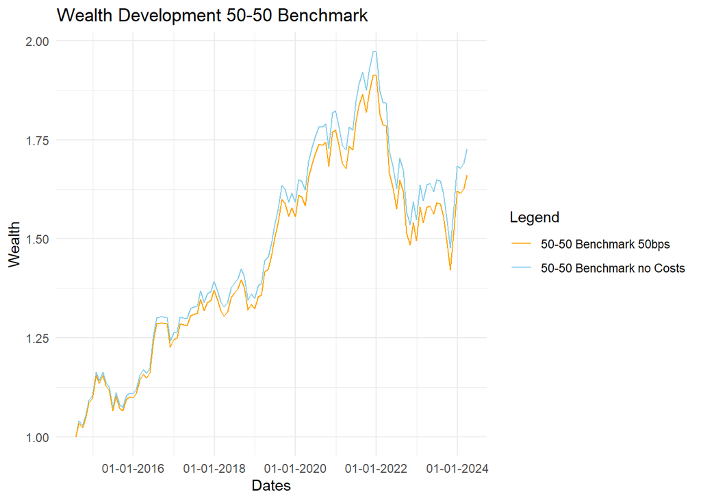

```r
# Extract out-of-sample dates
date <- index(eqBench.noCost$Wealth)

# Representation of EW and RW strategy each with noCost and 50bps scenario in one plot
ggplot(eqBench.noCost$Wealth) +
  geom_line(aes(x=date, y = Wealth, color = "50-50 Benchmark no Costs")) +
  geom_line(aes(x=date, y = eqBench.50bps$Wealth, color = "50-50 Benchmark 50bps")) +
  scale_x_date(labels = date_format("%d-%m-%Y")) +
  scale_color_manual("Legend", values = c("50-50 Benchmark no Costs" = "skyblue", "50-50 Benchmark 50bps" = "orange")) +
  labs(title = "Wealth Development 50-50 Benchmark", x = "Dates", y = "Wealth") +
  theme_minimal()
```

Now let’s have a look at the Maximum Drawdowns.

```r
# Show Maximum Drawdowns
rbind(EquallyWeightedBenchmark.noCosts = eqBench.noCost$maxDraw, EquallyWeightedBenchmark.50bps = eqBench.50bps$maxDraw)
```

```
##                                        From     Trough   To   Depth
## EquallyWeightedBenchmark.noCosts 2022-01-31 2023-10-31 <NA> -0.2517
## EquallyWeightedBenchmark.50bps   2022-01-31 2023-10-31 <NA> -0.2568
```

Last but not least, let’s compare the absolute and relative returns for the given scenarios

```r
# Display absolute and relative returns in a table:
returns.50_50Bench.Wealth <- list(EquallyWeightedBenchmark.abs.noCost = eqBench.noCost$abs.ret,
                                  EquallyWeightedBenchmark.abs.50bps = eqBench.50bps$abs.ret,
                                  EquallyWeightedBenchmark.rel.noCost = eqBench.noCost$rel.ret,
                                  EquallyWeightedBenchmark.rel.50bps = eqBench.50bps$rel.ret)

returns.50_50Bench.Wealth <- bind_rows(lapply(names(returns.50_50Bench.Wealth), function(name){
  data_frame <- data.frame(value = returns.50_50Bench.Wealth[[name]])
  data_frame$Type <- name  # Add the list name as a new column
  return(data_frame)
}))

returns.50_50Bench.Wealth <- returns.50_50Bench.Wealth %>%
    mutate(
      Strategy = ifelse(grepl("^EquallyWeightedBenchmark", Type), "Benchmark"),
      Return_Type = ifelse(grepl("rel", Type), "rel", "abs"),
      Cost = ifelse(grepl("noCost", Type), "noCost", "50bps")
      ) %>%
  select(-Type)

# Reshape the data to a wide format table
returns.50_50Bench.Wealth <- returns.50_50Bench.Wealth %>%
  pivot_wider(names_from = Return_Type, values_from = value) %>%
  arrange(Strategy, Cost)

returns.50_50Bench.Wealth
```

```
## # A tibble: 2 × 4
##   Strategy  Cost     abs   rel
##   <chr>     <chr>  <dbl> <dbl>
## 1 Benchmark 50bps  0.661 0.661
## 2 Benchmark noCost 0.727 0.727
```

### 3.4.2 Prevailing Mean Method

#### 3.4.2.1 Long-Only

We start by executing the wealth simulation.

```r
# Compute Wealth
EW.PR.noCost <- WEALTH.SIMULATION(ret = res.PR.L.O$ret.portf.EW$`No costs`$`Monthly Portfolio Return`, init = init)
EW.PR.50bps <- WEALTH.SIMULATION(ret = res.PR.L.O$ret.portf.EW$`50bps`$`Monthly Portfolio Return`, init = init)
RW.PR.noCost <- WEALTH.SIMULATION(ret = res.PR.L.O$ret.portf.RW$`No costs`$`Monthly Portfolio Return`, init = init)
RW.PR.50bps <- WEALTH.SIMULATION(ret = res.PR.L.O$ret.portf.RW$`50bps`$`Monthly Portfolio Return`, init = init)
```

Next, we plot the no cost scenario versus the 50bps TC scenario. Therefore, we first need to extract the out-of-sample dates.

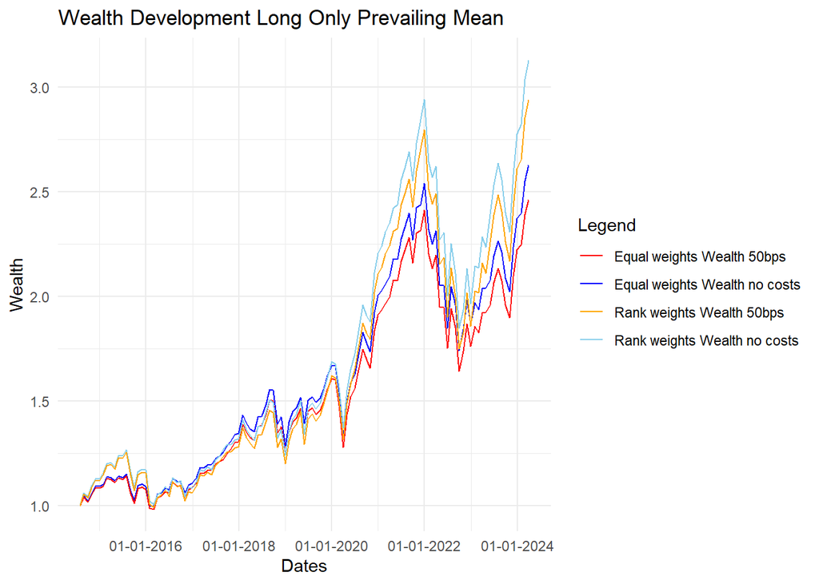

```r
# Extract out-of-sample dates
date <- index(EW.PR.noCost$Wealth)

# Representation of EW and RW strategy each with noCost and 50bps scenario in one plot
ggplot(EW.PR.noCost$Wealth) +
  geom_line(aes(x=date, y = Wealth, color = "Equal weights Wealth no costs")) +
  geom_line(aes(x=date, y = EW.PR.50bps$Wealth, color = "Equal weights Wealth 50bps")) +
  geom_line(aes(x=date, y = RW.PR.noCost$Wealth, color = "Rank weights Wealth no costs")) +
  geom_line(aes(x=date, y = RW.PR.50bps$Wealth, color = "Rank weights Wealth 50bps")) +
  scale_x_date(labels = date_format("%d-%m-%Y")) +
  scale_color_manual("Legend", values = c("Equal weights Wealth no costs" = "blue", "Equal weights Wealth 50bps" = "red",
                                          "Rank weights Wealth no costs" = "skyblue", "Rank weights Wealth 50bps" = "orange")) +
  labs(title = "Wealth Development Long Only Prevailing Mean", x = "Dates", y = "Wealth") +
  theme_minimal()
```

Now let’s have a look at the Maximum Drawdowns.

```r
# Show Maximum Drawdowns
rbind(EquallyWeighted.noCosts = EW.PR.noCost$maxDraw, EquallyWeighted.50bps = EW.PR.50bps$maxDraw,
      RankWeighted.noCosts = RW.PR.noCost$maxDraw, RankWeighted.50bps = RW.PR.50bps$maxDraw)
```

```
##                               From     Trough         To   Depth
## EquallyWeighted.noCosts 2022-01-31 2022-09-30 2024-02-29 -0.3148
## EquallyWeighted.50bps   2022-01-31 2022-09-30 2024-03-29 -0.3188
## RankWeighted.noCosts    2022-01-31 2022-09-30 2024-02-29 -0.3709
## RankWeighted.50bps      2022-01-31 2022-09-30 2024-02-29 -0.3739
```

Last but not least, let’s compare the absolute and relative returns for the given scenarios

```r
# Display absolute and relative returns in a table:
returns.PR.Wealth <- list(EW.abs.noCost = EW.PR.noCost$abs.ret, EW.abs.50bps = EW.PR.50bps$abs.ret,
                          EW.rel.noCost = EW.PR.noCost$rel.ret, EW.rel.50bps = EW.PR.50bps$rel.ret,
                          RW.abs.noCost = RW.PR.noCost$abs.ret, RW.abs.50bps = RW.PR.50bps$abs.ret,
                          RW.rel.noCost = RW.PR.noCost$rel.ret, RW.rel.50bps = RW.PR.50bps$rel.ret)

returns.PR.Wealth <- bind_rows(lapply(names(returns.PR.Wealth), function(name){
  data_frame <- data.frame(value = returns.PR.Wealth[[name]])
  data_frame$Type <- name  # Add the list name as a new column
  return(data_frame)
}))

# Extract `EW`/`RW`, `rel`/`abs`, and `noCost`/`50bps` from the `Type` column
returns.PR.Wealth <- returns.PR.Wealth %>%
    mutate(
      Strategy = ifelse(grepl("^EW", Type), "EW", "RW"),
      Return_Type = ifelse(grepl("rel", Type), "rel", "abs"),
      Cost = ifelse(grepl("noCost", Type), "noCost", "50bps")
      ) %>%
  select(-Type)  # Remove the original Type column

# Reshape the data to a wide format table
returns.PR.Wealth <- returns.PR.Wealth %>%
  pivot_wider(names_from = Return_Type, values_from = value) %>%
  arrange(Strategy, Cost)

returns.PR.Wealth
```

```
## # A tibble: 4 × 4
##   Strategy Cost     abs   rel
##   <chr>    <chr>  <dbl> <dbl>
## 1 EW       50bps   1.46  1.46
## 2 EW       noCost  1.63  1.63
## 3 RW       50bps   1.94  1.94
## 4 RW       noCost  2.13  2.13
```

#### 3.4.2.2 Long-Short Portfolio

We start by executing the wealth simulation.

```r
# Compute Wealth
EW.PR.noCost <- WEALTH.SIMULATION(ret = res.PR.L.S$ret.portf.EW$`No costs`$`Monthly Portfolio Return`, init = init)
EW.PR.50bps <- WEALTH.SIMULATION(ret = res.PR.L.S$ret.portf.EW$`50bps`$`Monthly Portfolio Return`, init = init)
RW.PR.noCost <- WEALTH.SIMULATION(ret = res.PR.L.S$ret.portf.RW$`No costs`$`Monthly Portfolio Return`, init = init)
RW.PR.50bps <- WEALTH.SIMULATION(ret = res.PR.L.S$ret.portf.RW$`50bps`$`Monthly Portfolio Return`, init = init)
```

Next, we plot the no cost scenario versus the 50bps TC scenario. Therefore, we first need to extract the out-of-sample dates.

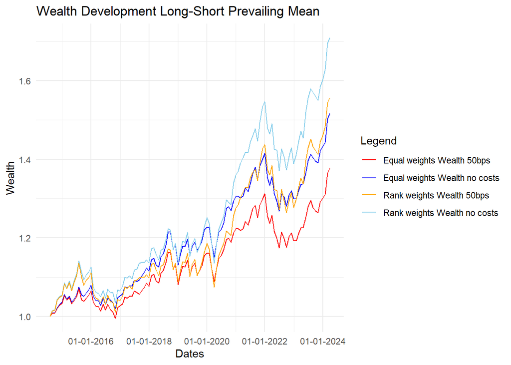

```r
# Extract out-of-sample dates
date <- index(EW.PR.noCost$Wealth)

# Representation of EW and RW strategy each with noCost and 50bps scenario in one plot
ggplot(EW.PR.noCost$Wealth) +
  geom_line(aes(x=date, y = Wealth, color = "Equal weights Wealth no costs")) +
  geom_line(aes(x=date, y = EW.PR.50bps$Wealth, color = "Equal weights Wealth 50bps")) +
  geom_line(aes(x=date, y = RW.PR.noCost$Wealth, color = "Rank weights Wealth no costs")) +
  geom_line(aes(x=date, y = RW.PR.50bps$Wealth, color = "Rank weights Wealth 50bps")) +
  scale_x_date(labels = date_format("%d-%m-%Y")) +
  scale_color_manual("Legend", values = c("Equal weights Wealth no costs" = "blue", "Equal weights Wealth 50bps" = "red",
                                          "Rank weights Wealth no costs" = "skyblue", "Rank weights Wealth 50bps" = "orange")) +
  labs(title = "Wealth Development Long-Short Prevailing Mean", x = "Dates", y = "Wealth") +
  theme_minimal()
```

Now let’s have a look at the Maximum Drawdowns.

```r
# Show Maximum Drawdowns
rbind(EquallyWeighted.noCosts = EW.PR.noCost$maxDraw, EquallyWeighted.50bps = EW.PR.50bps$maxDraw,
      RankWeighted.noCosts = RW.PR.noCost$maxDraw, RankWeighted.50bps = RW.PR.50bps$maxDraw)
```

```
##                               From     Trough         To   Depth
## EquallyWeighted.noCosts 2022-01-31 2022-06-30 2023-11-30 -0.1041
## EquallyWeighted.50bps   2022-01-31 2022-06-30 2024-02-29 -0.1056
## RankWeighted.noCosts    2022-01-31 2022-06-30 2023-06-30 -0.1140
## RankWeighted.50bps      2022-01-31 2022-09-30 2023-07-31 -0.1207
```

Last but not least, let’s compare the absolute and relative returns for the given scenarios

```r
# Display absolute and relative returns in a table:
returns.PR.Wealth <- list(EW.abs.noCost = EW.PR.noCost$abs.ret, EW.abs.50bps = EW.PR.50bps$abs.ret,
                          EW.rel.noCost = EW.PR.noCost$rel.ret, EW.rel.50bps = EW.PR.50bps$rel.ret,
                          RW.abs.noCost = RW.PR.noCost$abs.ret, RW.abs.50bps = RW.PR.50bps$abs.ret,
                          RW.rel.noCost = RW.PR.noCost$rel.ret, RW.rel.50bps = RW.PR.50bps$rel.ret)

returns.PR.Wealth <- bind_rows(lapply(names(returns.PR.Wealth), function(name){
  data_frame <- data.frame(value = returns.PR.Wealth[[name]])
  data_frame$Type <- name  # Add the list name as a new column
  return(data_frame)
}))

# Extract `EW`/`RW`, `rel`/`abs`, and `noCost`/`50bps` from the `Type` column
returns.PR.Wealth <- returns.PR.Wealth %>%
    mutate(Strategy = ifelse(grepl("^EW", Type), "EW", "RW"),
           Return_Type = ifelse(grepl("rel", Type), "rel", "abs"),
           Cost = ifelse(grepl("noCost", Type), "noCost", "50bps")
           ) %>%
  select(-Type)  # Remove the original Type column

# Reshape the data to a wide format table
returns.PR.Wealth <- returns.PR.Wealth %>%
  pivot_wider(names_from = Return_Type, values_from = value) %>%
  arrange(Strategy, Cost)

returns.PR.Wealth
```

```
## # A tibble: 4 × 4
##   Strategy Cost     abs   rel
##   <chr>    <chr>  <dbl> <dbl>
## 1 EW       50bps  0.378 0.378
## 2 EW       noCost 0.517 0.517
## 3 RW       50bps  0.557 0.557
## 4 RW       noCost 0.710 0.710
```

#### 3.4.2.3 Minimum Variance

We start by executing the wealth simulation.

```r
# Compute Wealth
MVsample.PR.noCost <- WEALTH.SIMULATION(ret = res.MV.PR$ret.portf.sample$`No costs`$`Monthly Portfolio Return`, init = init)
MVsample.PR.50bps <- WEALTH.SIMULATION(ret = res.MV.PR$ret.portf.sample$`50bps`$`Monthly Portfolio Return`, init = init)
MVshrink.PR.noCost <- WEALTH.SIMULATION(ret = res.MV.PR$ret.portf.shrink$`No costs`$`Monthly Portfolio Return`, init = init)
MVshrink.PR.50bps <- WEALTH.SIMULATION(ret = res.MV.PR$ret.portf.shrink$`50bps`$`Monthly Portfolio Return`, init = init)
```

Next, we plot the no cost scenario versus the 50bps TC scenario. Therefore, we first need to extract the out-of-sample dates.

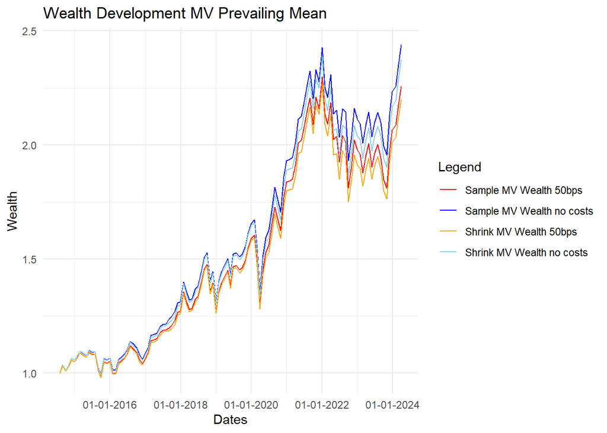

```r
# Extract out-of-sample dates
date <- index(MVsample.PR.noCost$Wealth)

# Representation of EW and RW strategy each with noCost and 50bps scenario in one plot
ggplot(MVsample.PR.noCost$Wealth) +
  geom_line(aes(x=date, y = Wealth, color = "Sample MV Wealth no costs")) +
  geom_line(aes(x=date, y = MVsample.PR.50bps$Wealth, color = "Sample MV Wealth 50bps")) +
  geom_line(aes(x=date, y = MVshrink.PR.noCost$Wealth, color = "Shrink MV Wealth no costs")) +
  geom_line(aes(x=date, y = MVshrink.PR.50bps$Wealth, color = "Shrink MV Wealth 50bps")) +
  scale_x_date(labels = date_format("%d-%m-%Y")) +
  scale_color_manual("Legend", values = c("Sample MV Wealth no costs" = "blue", "Sample MV Wealth 50bps" = "red",
                                          "Shrink MV Wealth no costs" = "skyblue", "Shrink MV Wealth 50bps" = "orange")) +
  labs(title = "Wealth Development MV Prevailing Mean", x = "Dates", y = "Wealth") +
  theme_minimal()
```

Now let’s have a look at the Maximum Drawdowns.

```r
# Show Maximum Drawdowns
rbind(SampleMV.noCosts = MVsample.PR.noCost$maxDraw, SampleMV.50bps = MVsample.PR.50bps$maxDraw,
      ShrinkMV.noCosts = MVshrink.PR.noCost$maxDraw, ShrinkMV.PR.50bps = MVshrink.PR.50bps$maxDraw)
```

```
##                         From     Trough         To   Depth
## SampleMV.noCosts  2022-01-31 2022-09-30 2024-03-29 -0.2039
## SampleMV.50bps    2022-01-31 2022-09-30       <NA> -0.2128
## ShrinkMV.noCosts  2022-01-31 2022-09-30       <NA> -0.2190
## ShrinkMV.PR.50bps 2022-01-31 2022-09-30       <NA> -0.2274
```

Last but not least, let’s compare the absolute and relative returns for the given scenarios

```r
# Display absolute and relative returns in a table:
returns.MV.PR.Wealth <- list(MVsample.abs.noCost = MVsample.PR.noCost$abs.ret, MVsample.abs.50bps = MVsample.PR.50bps$abs.ret,
                             MVsample.rel.noCost = MVsample.PR.noCost$rel.ret, MVsample.rel.50bps = MVsample.PR.50bps$rel.ret,
                             MVshrink.abs.noCost = MVshrink.PR.noCost$abs.ret, MVshrink.abs.50bps = MVshrink.PR.50bps$abs.ret,
                             MVshrink.rel.noCost = MVshrink.PR.noCost$rel.ret, MVshrink.rel.50bps = MVshrink.PR.50bps$rel.ret)

returns.MV.PR.Wealth <- bind_rows(lapply(names(returns.MV.PR.Wealth), function(name){
  data_frame <- data.frame(value = returns.MV.PR.Wealth[[name]])
  data_frame$Type <- name  # Add the list name as a new column
  return(data_frame)
}))

# Extract `EW`/`RW`, `rel`/`abs`, and `noCost`/`50bps` from the `Type` column
returns.MV.PR.Wealth <- returns.MV.PR.Wealth %>%
  mutate(Strategy = ifelse(grepl("^MVsample", Type), "sample", "shrink"),
         Return_Type = ifelse(grepl("rel", Type), "rel", "abs"),
         Cost = ifelse(grepl("noCost", Type), "noCost", "50bps")
         ) %>%
  select(-Type)  # Remove the original Type column

# Reshape the data to a wide format table
returns.MV.PR.Wealth <- returns.MV.PR.Wealth %>%
  pivot_wider(names_from = Return_Type, values_from = value) %>%
  arrange(Strategy, Cost)

returns.MV.PR.Wealth
```

```
## # A tibble: 4 × 4
##   Strategy Cost     abs   rel
##   <chr>    <chr>  <dbl> <dbl>
## 1 sample   50bps   1.26  1.26
## 2 sample   noCost  1.44  1.44
## 3 shrink   50bps   1.20  1.20
## 4 shrink   noCost  1.37  1.37
```

### 3.4.3 Random Forest Method

#### 3.4.3.1 Long-Only

We start by executing the wealth simulation.

```r
# Compute Wealth
EW.RF.noCost <- WEALTH.SIMULATION(ret = res.RF.L.O$ret.portf.EW$`No costs`$`Monthly Portfolio Return`, init = init)
EW.RF.50bps <- WEALTH.SIMULATION(ret = res.RF.L.O$ret.portf.EW$`50bps`$`Monthly Portfolio Return`, init = init)
RW.RF.noCost <- WEALTH.SIMULATION(ret = res.RF.L.O$ret.portf.RW$`No costs`$`Monthly Portfolio Return`, init = init)
RW.RF.50bps <- WEALTH.SIMULATION(ret = res.RF.L.O$ret.portf.RW$`50bps`$`Monthly Portfolio Return`, init = init)
```

Next, we plot the no cost scenario versus the 50bps TC scenario. Therefore, we first need to extract the out-of-sample dates.

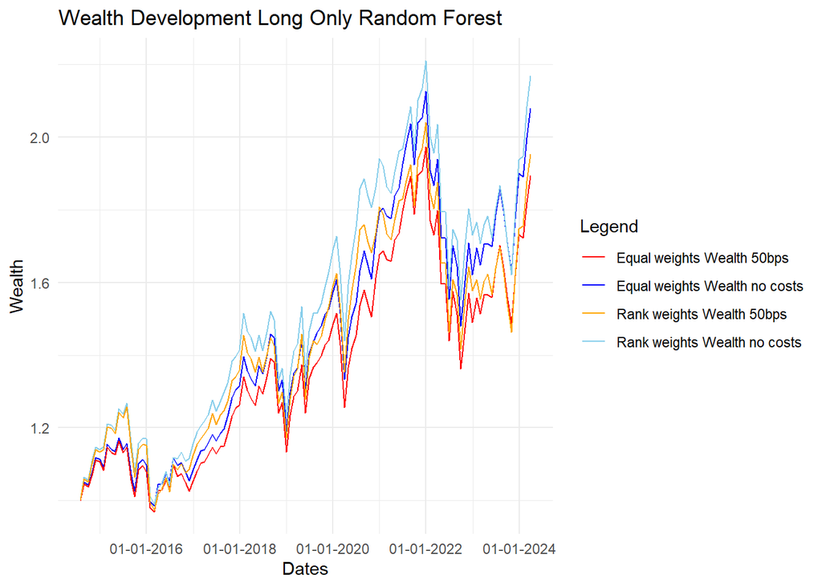

```r
# Extract out-of-sample dates
date <- index(EW.RF.noCost$Wealth)

# Representation of EW and RW strategy each with noCost and 50bps scenario in one plot
ggplot(EW.RF.noCost$Wealth) +
  geom_line(aes(x=date, y = Wealth, color = "Equal weights Wealth no costs")) +
  geom_line(aes(x=date, y = EW.RF.50bps$Wealth, color = "Equal weights Wealth 50bps")) +
  geom_line(aes(x=date, y = RW.RF.noCost$Wealth, color = "Rank weights Wealth no costs")) +
  geom_line(aes(x=date, y = RW.RF.50bps$Wealth, color = "Rank weights Wealth 50bps")) +
  scale_x_date(labels = date_format("%d-%m-%Y")) +
  scale_color_manual("Legend", values = c("Equal weights Wealth no costs" = "blue", "Equal weights Wealth 50bps" = "red",
                                          "Rank weights Wealth no costs" = "skyblue", "Rank weights Wealth 50bps" = "orange")) +
  labs(title = "Wealth Development Long Only Random Forest", x = "Dates", y = "Wealth") +
  theme_minimal()
```

Now let’s have a look at the Maximum Drawdowns.

```r
# Show Maximum Drawdowns
rbind(EquallyWeighted.noCosts = EW.RF.noCost$maxDraw, EquallyWeighted.50bps = EW.RF.50bps$maxDraw,
      RankWeighted.noCosts = RW.RF.noCost$maxDraw, RankWeighted.50bps = RW.RF.50bps$maxDraw)
```

```
##                               From     Trough   To   Depth
## EquallyWeighted.noCosts 2022-01-31 2022-09-30 <NA> -0.3036
## EquallyWeighted.50bps   2022-01-31 2022-09-30 <NA> -0.3100
## RankWeighted.noCosts    2022-01-31 2022-09-30 <NA> -0.2978
## RankWeighted.50bps      2022-01-31 2022-09-30 <NA> -0.3058
```

Last but not least, let’s compare the absolute and relative returns for the given scenarios

```r
# Display absolute and relative returns in a table:
returns.RF.Wealth <- list(EW.abs.noCost = EW.RF.noCost$abs.ret, EW.abs.50bps = EW.RF.50bps$abs.ret,
                          EW.rel.noCost = EW.RF.noCost$rel.ret, EW.rel.50bps = EW.RF.50bps$rel.ret,
                          RW.abs.noCost = RW.RF.noCost$abs.ret, RW.abs.50bps = RW.RF.50bps$abs.ret,
                          RW.rel.noCost = RW.RF.noCost$rel.ret, RW.rel.50bps = RW.RF.50bps$rel.ret)

returns.RF.Wealth <- bind_rows(lapply(names(returns.RF.Wealth), function(name){
  data_frame <- data.frame(value = returns.RF.Wealth[[name]])
  data_frame$Type <- name  # Add the list name as a new column
  return(data_frame)
}))

# Extract `EW`/`RW`, `rel`/`abs`, and `noCost`/`50bps` from the `Type` column
returns.RF.Wealth <- returns.RF.Wealth %>%
    mutate(
      Strategy = ifelse(grepl("^EW", Type), "EW", "RW"),
      Return_Type = ifelse(grepl("rel", Type), "rel", "abs"),
      Cost = ifelse(grepl("50bps", Type), "50bps", "noCost")) %>%
  select(-Type)  # Remove the original Type column

# Reshape the data to a wide format table
returns.RF.Wealth <- returns.RF.Wealth %>%
  pivot_wider(names_from = Return_Type, values_from = value) %>%
  arrange(Strategy, Cost)

returns.RF.Wealth
```

```
## # A tibble: 4 × 4
##   Strategy Cost     abs   rel
##   <chr>    <chr>  <dbl> <dbl>
## 1 EW       50bps  0.894 0.894
## 2 EW       noCost 1.08  1.08
## 3 RW       50bps  0.953 0.953
## 4 RW       noCost 1.17  1.17
```

#### 3.3.3.2 Long-Short Portfolio

We start by executing the wealth simulation.

```r
# Compute Wealth
EW.RF.noCost <- WEALTH.SIMULATION(ret = res.RF.L.S$ret.portf.EW$`No costs`$`Monthly Portfolio Return`, init = init)
EW.RF.50bps <- WEALTH.SIMULATION(ret = res.RF.L.S$ret.portf.EW$`50bps`$`Monthly Portfolio Return`, init = init)
RW.RF.noCost <- WEALTH.SIMULATION(ret = res.RF.L.S$ret.portf.RW$`No costs`$`Monthly Portfolio Return`, init = init)
RW.RF.50bps <- WEALTH.SIMULATION(ret = res.RF.L.S$ret.portf.RW$`50bps`$`Monthly Portfolio Return`, init = init)
```

Next, we plot the no cost scenario versus the 50bps TC scenario. Therefore, we first need to extract the out-of-sample dates.

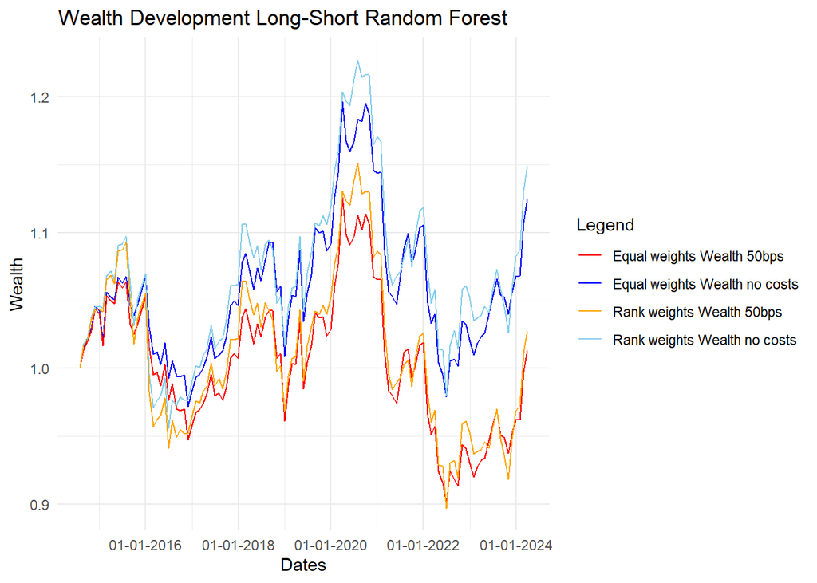

```r
# Extract out-of-sample dates
date <- index(EW.RF.noCost$Wealth)

# Representation of EW and RW strategy each with noCost and 50bps scenario in one plot
ggplot(EW.RF.noCost$Wealth) +
  geom_line(aes(x=date, y = Wealth, color = "Equal weights Wealth no costs")) +
  geom_line(aes(x=date, y = EW.RF.50bps$Wealth, color = "Equal weights Wealth 50bps")) +
  geom_line(aes(x=date, y = RW.RF.noCost$Wealth, color = "Rank weights Wealth no costs")) +
  geom_line(aes(x=date, y = RW.RF.50bps$Wealth, color = "Rank weights Wealth 50bps")) +
  scale_x_date(labels = date_format("%d-%m-%Y")) +
  scale_color_manual("Legend", values = c("Equal weights Wealth no costs" = "blue", "Equal weights Wealth 50bps" = "red",
                                          "Rank weights Wealth no costs" = "skyblue", "Rank weights Wealth 50bps" = "orange")) +
  labs(title = "Wealth Development Long-Short Random Forest", x = "Dates", y = "Wealth") +
  theme_minimal()
```

Now let’s have a look at the Maximum Drawdowns.

```r
# Show Maximum Drawdowns
rbind(EquallyWeighted.noCosts = EW.RF.noCost$maxDraw, EquallyWeighted.50bps = EW.RF.50bps$maxDraw,
      RankWeighted.noCosts = RW.RF.noCost$maxDraw, RankWeighted.50bps = RW.RF.50bps$maxDraw)
```

```
##                               From     Trough   To   Depth
## EquallyWeighted.noCosts 2020-04-30 2022-06-30 <NA> -0.1814
## EquallyWeighted.50bps   2020-04-30 2022-06-30 <NA> -0.2002
## RankWeighted.noCosts    2020-08-31 2022-06-30 <NA> -0.2012
## RankWeighted.50bps      2020-08-31 2022-06-30 <NA> -0.2207
```

Last but not least, let’s compare the absolute and relative returns for the given scenarios

```r
# Display absolute and relative returns in a table:
returns.RF.Wealth <- list(EW.abs.noCost = EW.RF.noCost$abs.ret, EW.abs.50bps = EW.RF.50bps$abs.ret,
                          EW.rel.noCost = EW.RF.noCost$rel.ret, EW.rel.50bps = EW.RF.50bps$rel.ret,
                          RW.abs.noCost = RW.RF.noCost$abs.ret, RW.abs.50bps = RW.RF.50bps$abs.ret,
                          RW.rel.noCost = RW.RF.noCost$rel.ret, RW.rel.50bps = RW.RF.50bps$rel.ret)

returns.RF.Wealth <- bind_rows(lapply(names(returns.RF.Wealth), function(name){
  data_frame <- data.frame(value = returns.RF.Wealth[[name]])
  data_frame$Type <- name  # Add the list name as a new column
  return(data_frame)
}))

# Extract `EW`/`RW`, `rel`/`abs`, and `noCost`/`50bps` from the `Type` column
returns.RF.Wealth <- returns.RF.Wealth %>%
    mutate(Strategy = ifelse(grepl("^EW", Type), "EW", "RW"),
           Return_Type = ifelse(grepl("rel", Type), "rel", "abs"),
           Cost = ifelse(grepl("noCost", Type), "noCost", "50bps")
           ) %>%
  select(-Type)  # Remove the original Type column

# Reshape the data to a wide format table
returns.RF.Wealth <- returns.RF.Wealth %>%
  pivot_wider(names_from = Return_Type, values_from = value) %>%
  arrange(Strategy, Cost)

returns.RF.Wealth
```

```
## # A tibble: 4 × 4
##   Strategy Cost      abs    rel
##   <chr>    <chr>   <dbl>  <dbl>
## 1 EW       50bps  0.0133 0.0133
## 2 EW       noCost 0.125  0.125
## 3 RW       50bps  0.0275 0.0275
## 4 RW       noCost 0.149  0.149
```

#### 3.4.3.3 Minimum Variance

We start by executing the wealth simulation.

```r
# Compute Wealth
MVsample.RF.noCost <- WEALTH.SIMULATION(ret = res.MV.RF$ret.portf.sample$`No costs`$`Monthly Portfolio Return`, init = init)
MVsample.RF.50bps <- WEALTH.SIMULATION(ret = res.MV.RF$ret.portf.sample$`50bps`$`Monthly Portfolio Return`, init = init)
MVshrink.RF.noCost <- WEALTH.SIMULATION(ret = res.MV.RF$ret.portf.shrink$`No costs`$`Monthly Portfolio Return`, init = init)
MVshrink.RF.50bps <- WEALTH.SIMULATION(ret = res.MV.RF$ret.portf.shrink$`50bps`$`Monthly Portfolio Return`, init = init)
```

Next, we plot the no cost scenario versus the 50bps TC scenario. Therefore, we first need to extract the out-of-sample dates.

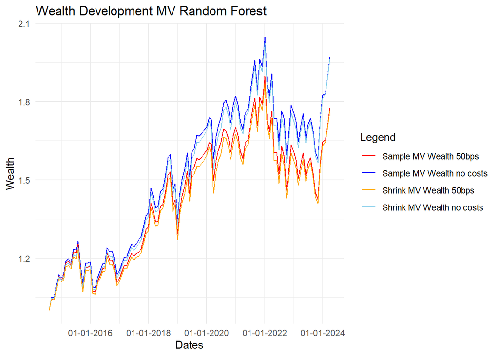

```r
# Extract out-of-sample dates
date <- index(MVsample.RF.noCost$Wealth)

# Representation of EW and RW strategy each with noCost and 50bps scenario in one plot
ggplot(MVsample.RF.noCost$Wealth) +
  geom_line(aes(x=date, y = Wealth, color = "Sample MV Wealth no costs")) +
  geom_line(aes(x=date, y = MVsample.RF.50bps$Wealth, color = "Sample MV Wealth 50bps")) +
  geom_line(aes(x=date, y = MVshrink.RF.noCost$Wealth, color = "Shrink MV Wealth no costs")) +
  geom_line(aes(x=date, y = MVshrink.RF.50bps$Wealth, color = "Shrink MV Wealth 50bps")) +
  scale_x_date(labels = date_format("%d-%m-%Y")) +
  scale_color_manual("Legend", values = c("Sample MV Wealth no costs" = "blue", "Sample MV Wealth 50bps" = "red",
                                          "Shrink MV Wealth no costs" = "skyblue", "Shrink MV Wealth 50bps" = "orange")) +
  labs(title = "Wealth Development MV Random Forest", x = "Dates", y = "Wealth") +
  theme_minimal()
```

Now let’s have a look at the Maximum Drawdowns.

```r
# Show Maximum Drawdowns
rbind(SampleMV.noCosts = MVsample.RF.noCost$maxDraw, SampleMV.50bps = MVsample.RF.50bps$maxDraw,
      ShrinkMV.noCosts = MVshrink.RF.noCost$maxDraw, ShrinkMV.PR.50bps = MVshrink.RF.50bps$maxDraw)
```

```
##                         From     Trough   To   Depth
## SampleMV.noCosts  2022-01-31 2023-10-31 <NA> -0.2294
## SampleMV.50bps    2022-01-31 2023-10-31 <NA> -0.2481
## ShrinkMV.noCosts  2022-01-31 2023-10-31 <NA> -0.2274
## ShrinkMV.PR.50bps 2022-01-31 2023-10-31 <NA> -0.2461
```

Last but not least, let’s compare the absolute and relative returns for the given scenarios

```r
# Display absolute and relative returns in a table:
returns.MV.RF.Wealth <- list(MVsample.abs.noCost = MVsample.RF.noCost$abs.ret, MVsample.abs.50bps = MVsample.RF.50bps$abs.ret,
                             MVsample.rel.noCost = MVsample.RF.noCost$rel.ret, MVsample.rel.50bps = MVsample.RF.50bps$rel.ret,
                             MVshrink.abs.noCost = MVshrink.RF.noCost$abs.ret, MVshrink.abs.50bps = MVshrink.RF.50bps$abs.ret,
                             MVshrink.rel.noCost = MVshrink.RF.noCost$rel.ret, MVshrink.rel.50bps = MVshrink.RF.50bps$rel.ret)

returns.MV.RF.Wealth <- bind_rows(lapply(names(returns.MV.RF.Wealth), function(name){
  data_frame <- data.frame(value = returns.MV.RF.Wealth[[name]])
  data_frame$Type <- name  # Add the list name as a new column
  return(data_frame)
}))

# Extract `EW`/`RW`, `rel`/`abs`, and `noCost`/`50bps` from the `Type` column
returns.MV.RF.Wealth <- returns.MV.RF.Wealth %>%
  mutate(Strategy = ifelse(grepl("^MVsample", Type), "sample", "shrink"),
         Return_Type = ifelse(grepl("rel", Type), "rel", "abs"),
         Cost = ifelse(grepl("noCost", Type), "noCost", "50bps")
         ) %>%
  select(-Type)  # Remove the original Type column

# Reshape the data to a wide format table
returns.MV.RF.Wealth <- returns.MV.RF.Wealth %>%
  pivot_wider(names_from = Return_Type, values_from = value) %>%
  arrange(Strategy, Cost)

returns.MV.RF.Wealth
```

```
## # A tibble: 4 × 4
##   Strategy Cost     abs   rel
##   <chr>    <chr>  <dbl> <dbl>
## 1 sample   50bps  0.776 0.776
## 2 sample   noCost 0.969 0.969
## 3 shrink   50bps  0.765 0.765
## 4 shrink   noCost 0.963 0.963
```

### 3.4.4 Minimum Variance Raw

We start by executing the wealth simulation.

```r
# Compute Wealth
MVsample.raw.noCost <- WEALTH.SIMULATION(ret = res.MV.raw$ret.portf.sample$`No costs`$`Monthly Portfolio Return`, init = init)
MVsample.raw.50bps <- WEALTH.SIMULATION(ret = res.MV.raw$ret.portf.sample$`50bps`$`Monthly Portfolio Return`, init = init)
MVshrink.raw.noCost <- WEALTH.SIMULATION(ret = res.MV.raw$ret.portf.shrink$`No costs`$`Monthly Portfolio Return`, init = init)
MVshrink.raw.50bps <- WEALTH.SIMULATION(ret = res.MV.raw$ret.portf.shrink$`50bps`$`Monthly Portfolio Return`, init = init)
```

Next, we plot the no cost scenario versus the 50bps TC scenario. Therefore, we first need to extract the out-of-sample dates.

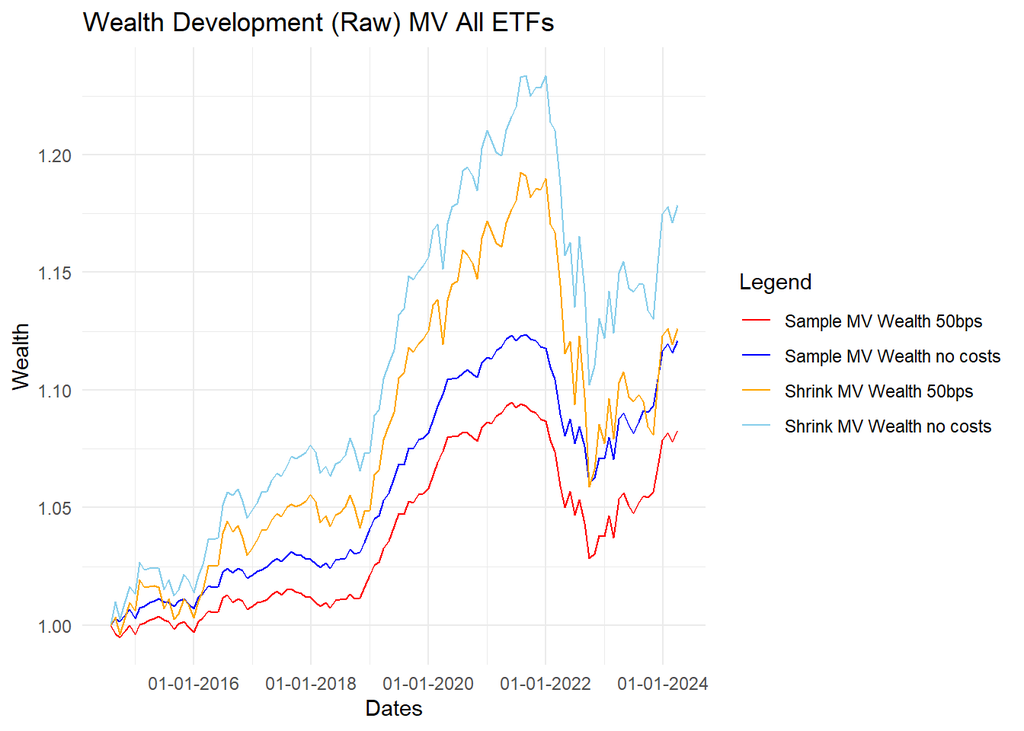

```r
# Extract out-of-sample dates
date <- index(MVsample.raw.noCost$Wealth)

# Representation of EW and RW strategy each with noCost and 50bps scenario in one plot
ggplot(MVsample.raw.noCost$Wealth) +
  geom_line(aes(x=date, y = Wealth, color = "Sample MV Wealth no costs")) +
  geom_line(aes(x=date, y = MVsample.raw.50bps$Wealth, color = "Sample MV Wealth 50bps")) +
  geom_line(aes(x=date, y = MVshrink.raw.noCost$Wealth, color = "Shrink MV Wealth no costs")) +
  geom_line(aes(x=date, y = MVshrink.raw.50bps$Wealth, color = "Shrink MV Wealth 50bps")) +
  scale_x_date(labels = date_format("%d-%m-%Y")) +
  scale_color_manual("Legend", values = c("Sample MV Wealth no costs" = "blue", "Sample MV Wealth 50bps" = "red",
                                          "Shrink MV Wealth no costs" = "skyblue", "Shrink MV Wealth 50bps" = "orange")) +
  labs(title = "Wealth Development (Raw) MV All ETFs", x = "Dates", y = "Wealth") +
  theme_minimal()
```

Now let’s have a look at the Maximum Drawdowns.

```r
# Show Maximum Drawdowns
rbind(SampleMV.noCosts = MVsample.raw.noCost$maxDraw, SampleMV.50bps = MVsample.raw.50bps$maxDraw,
      ShrinkMV.noCosts = MVshrink.raw.noCost$maxDraw, ShrinkMV.PR.50bps = MVshrink.raw.50bps$maxDraw)
```

```
##                         From     Trough   To   Depth
## SampleMV.noCosts  2021-09-30 2022-09-30 <NA> -0.0561
## SampleMV.50bps    2021-06-30 2022-09-30 <NA> -0.0609
## ShrinkMV.noCosts  2022-01-31 2022-09-30 <NA> -0.1066
## ShrinkMV.PR.50bps 2021-08-31 2022-09-30 <NA> -0.1121
```

Last but not least, let’s compare the absolute and relative returns for the given scenarios

```r
# Display absolute and relative returns in a table:
returns.MV.raw.Wealth <- list(MVsample.abs.noCost = MVsample.raw.noCost$abs.ret, MVsample.abs.50bps = MVsample.raw.50bps$abs.ret,
                             MVsample.rel.noCost = MVsample.raw.noCost$rel.ret, MVsample.rel.50bps = MVsample.raw.50bps$rel.ret,
                             MVshrink.abs.noCost = MVshrink.raw.noCost$abs.ret, MVshrink.abs.50bps = MVshrink.raw.50bps$abs.ret,
                             MVshrink.rel.noCost = MVshrink.raw.noCost$rel.ret, MVshrink.rel.50bps = MVshrink.raw.50bps$rel.ret)

returns.MV.raw.Wealth <- bind_rows(lapply(names(returns.MV.raw.Wealth), function(name){
  data_frame <- data.frame(value = returns.MV.raw.Wealth[[name]])
  data_frame$Type <- name  # Add the list name as a new column
  return(data_frame)
}))

# Extract `EW`/`RW`, `rel`/`abs`, and `noCost`/`50bps` from the `Type` column
returns.MV.raw.Wealth <- returns.MV.raw.Wealth %>%
  mutate(Strategy = ifelse(grepl("^MVsample", Type), "sample", "shrink"),
         Return_Type = ifelse(grepl("rel", Type), "rel", "abs"),
         Cost = ifelse(grepl("noCost", Type), "noCost", "50bps")
         ) %>%
  select(-Type)  # Remove the original Type column

# Reshape the data to a wide format table
returns.MV.raw.Wealth <- returns.MV.raw.Wealth %>%
  pivot_wider(names_from = Return_Type, values_from = value) %>%
  arrange(Strategy, Cost)

returns.MV.raw.Wealth
```

```
## # A tibble: 4 × 4
##   Strategy Cost      abs    rel
##   <chr>    <chr>   <dbl>  <dbl>
## 1 sample   50bps  0.0830 0.0830
## 2 sample   noCost 0.121  0.121
## 3 shrink   50bps  0.126  0.126
## 4 shrink   noCost 0.179  0.179
```

## 3.5 Robustnesscheck

### 3.5.1 Adaptation of the Forecasting Horizon

### 3.5.2 Adaptation of the Training Data Set

### 3.5.3 Adaptation of the Portfolio Construction Techniques

### 3.5.4 Execution of Input Parameter Combinations

To get a more complete picture regarding the stability against the input parameters we now create a large set of input parameter combinations and analyze the grouped summary statistics more closely. Since running the code again for hundreds of different input combinations means a huge computational effort, we perform this **without** hyperparameter tuning via cross-validation and with 500 trees per forest.

```r
tune_grid <- NULL
train_control <- trainControl(method = "none")
lookback <-c(5*12,2*12,12)
train.perc <- c(0.5, 0.3, 0.7)
lag <- c(12,3*12,5*12,7*12)
horizon <- c(12,6,1)
limit <- c(NA,4*12, 7*12)
use <- c(0.25,0.5,1)
n.trees <- 500

# Create the combinations
input.grid <- expand.grid(lookback, train.perc, lag, horizon, limit, use)
colnames(input.grid) <- c("lookback", "train.perc", "lag", "horizon", "limit", "use")

# Remove combinations for which the RF predictions can't be computed
input.grid <- filter(input.grid, is.na(limit) | limit - lag >= horizon + 1)
input.grid <- filter(input.grid, round(train.perc*nrow(ret),0) - lag >= horizon + 1)

# Shuffle the table in case you can't have not much time available
input.grid <- input.grid[sample(nrow(input.grid)), ]
# In this case you get a better picture of the impact of different combinations
# Because the combinations are created systematically by columns.
# Hence, after 20 min or so you might only get a picture of what the impact is, when you differ the combination between lookback and train.perc

# Create list to store the performance results in
results.perf <- vector("list", length = nrow(input.grid))
results.perf <- lapply(1:length(results.perf), function(x){ results.perf[[x]] <- input.grid[x,]})

for(x in 1:nrow(input.grid)){

  print(x)

  # EXTRACT INPUT PARAMETERS
  tryCatch({lookback <- input.grid$lookback[x]
  train.perc <- input.grid$train.perc[x]
  lag <- input.grid$lag[x]
  horizon <- input.grid$horizon[x]
  limit <- input.grid$limit[x]
  use.long.only <- input.grid$use[x]
  use.long.short <- input.grid$use[x]
  use.long.minvar <- input.grid$use[x]

  ###############################################################################################
  # PREVAILING MEAN
  # Initial number of training rows:
  train.rows <- Train.Rows(ret = ret, train.perc = train.perc)
  # All test values:
  y_test <- Test_DS(ret = ret, train.rows = train.rows, horizon = horizon)

  mean.ret.mon.all <- NULL
  mean.ret.cum.all <- NULL
  t=1

  ## Start predictions:
  while(t<nrow(y_test$y_test)){

    res.prev <- PREVAILING.MEAN(ret = ret, horizon = horizon,
                                train.rows = train.rows, limit = limit,
                                counter = t, mean.ret.mon.all = mean.ret.mon.all,
                                mean.ret.cum.all = mean.ret.cum.all,
                                y_test = y_test$y_test)

    t <- res.prev$counter
    train.rows <- res.prev$train.rows
    mean.ret.mon.all <- res.prev$mean.ret.mon.all
    mean.ret.cum.all <- res.prev$mean.ret.cum.all

  }
  rownames(mean.ret.cum.all) <- c(1:nrow(mean.ret.cum.all))
  eval.pr.mean <- EVAL(y_predictions = mean.ret.mon.all, y_actual = y_test$y_test,
                       y_predictions.cum = mean.ret.cum.all,
                       y_actual.cum = y_test$y_test.cum)
  eval.pr.mean <- do.call(rbind, eval.pr.mean)

  ###############################################################################################

  #RANDOM FOREST
  # Initial number of training rows:
  train.rows <- Train.Rows(ret = ret, train.perc = train.perc)
  # Compute EMAs with max. 5 years of data laying back for Macro variables:
  macro.ema <- TRANS.MACRO(data = macro, lookback = lookback)
  # All test values
  y_test <- Test_DS(ret = ret, train.rows = train.rows, horizon = horizon)
  if(!is.null(clusters)){
    print("!!Attention: You set the variable clusters. Don't perform several other (complex) parallel tasks on your machine while the loop is running!!")
  }
  t=1

  ## Start predictions:
  while(t<nrow(y_test$y_test)){

    input <- Train_DS(ret = ret, macro.ema = macro.ema, train.rows = train.rows,
                      lag = lag, limit = limit)

    res <- RANDOM_FOREST(input = input, horizon = horizon, y_test = y_test,counter =  t, old.forecasts = old.forecasts,
                         cum.perf = cum.perf, tune_grid = tune_grid, train_control = train_control, clusters = clusters,
                         limit = limit, n.trees = n.trees)

    t <- res$counter
    train.rows <- res$train.rows
    old.forecasts <- res$old.forecasts
    cum.perf <- res$cum.perf

  }
  ## Extract return predictions:
  monthly.pred <- do.call(cbind, res$old.forecasts)
  cumulative.pred <- do.call(cbind, res$cum.perf)

  eval.RF <- EVAL(y_predictions = res$old.forecasts, y_actual = y_test$y_test,
               y_predictions.cum = res$cum.perf, y_actual.cum = y_test$y_test.cum)
  eval.RF <- do.call(rbind, eval.RF)

  ###############################################################################################

  ###################
  #### BACKTESTS ####
  ###################


  ###############################################################################################
  # LO PR
  print("LO PR")
  train.rows <- Train.Rows(ret = ret, train.perc = train.perc)
  y_test <- Test_DS(ret = ret, train.rows = train.rows, horizon = horizon)
  counter = 1
  t = 1
  portf.EW.all <- list()
  portf.RW.all <- list()
  all.ret.mon.portf.EW <- NULL
  all.ret.mon.portf.RW <- NULL
  res.PR.L.O <- NULL

  ## Start the backtest
  while(counter < nrow(y_test$y_test)){

    #print(t)

    res.PR.L.O <- LONG.ONLY(y_test = y_test$y_test, cum.pred = mean.ret.cum.all, use.long.only = use.long.only,
                            counter = counter, t = t, horizon = horizon, portf.EW.all = portf.EW.all, portf.RW.all = portf.RW.all,
                            all.ret.mon.portf.EW = all.ret.mon.portf.EW, all.ret.mon.portf.RW = all.ret.mon.portf.RW, fix.tc = fix.tc,
                            trans.costs = trans.costs, TER.monthly = TER.monthly, res.all = res.PR.L.O)

    t <- res.PR.L.O$t
    counter <- res.PR.L.O$counter
    # Extract initial weights
    portf.EW.all <- res.PR.L.O$portf.EW.all
    portf.RW.all <- res.PR.L.O$portf.RW.all
    # All other performance results
    all.ret.mon.portf.EW <- res.PR.L.O$ret.portf.EW$`No costs`$`Monthly Portfolio Return`
    all.ret.mon.portf.RW <- res.PR.L.O$ret.portf.RW$`No costs`$`Monthly Portfolio Return`
  }
```

```r
  ## Summary statistics:
  # EW:
  stat.EW.L.O.PR <- STATISTICS(res = res.PR.L.O$ret.portf.EW, RF = rf, VaR.CI = VaR.CI, horizon = horizon, trans.costs = trans.costs)
  # RW:
  stat.RW.L.O.PR <- STATISTICS(res = res.PR.L.O$ret.portf.RW, RF = rf, VaR.CI = VaR.CI, horizon = horizon, trans.costs = trans.costs)
  LO.PR <- list(Equally.Weighted.L.O = stat.EW.L.O.PR, Rank.Weighted.L.O = stat.RW.L.O.PR)

  ###############################################################################################

  # LO RF
  print("LO RF")
  train.rows <- Train.Rows(ret = ret, train.perc = train.perc)
  y_test <- Test_DS(ret = ret, train.rows = train.rows, horizon = horizon)
  counter = 1
  t = 1
  portf.EW.all <- list()
  portf.RW.all <- list()
  all.ret.mon.portf.EW <- NULL
  all.ret.mon.portf.RW <- NULL
  res.RF.L.O <- NULL
  cumulative.pred <- as.matrix(cumulative.pred)
  colnames(cumulative.pred) <- colnames(mean.ret.cum.all)

  ## Start the backtest
  while(counter < nrow(y_test$y_test)){

    #print(t)

    res.RF.L.O <- LONG.ONLY(y_test = y_test$y_test, cum.pred = cumulative.pred, use.long.only = use.long.only,
                            counter = counter, t = t, horizon = horizon, portf.EW.all = portf.EW.all, portf.RW.all = portf.RW.all,
                            all.ret.mon.portf.EW = all.ret.mon.portf.EW, all.ret.mon.portf.RW = all.ret.mon.portf.RW, fix.tc = fix.tc,
                            trans.costs = trans.costs, TER.monthly = TER.monthly, res.all = res.RF.L.O)

    t <- res.RF.L.O$t
    counter <- res.RF.L.O$counter
    # Extract initial weights
    portf.EW.all <- res.RF.L.O$portf.EW.all
    portf.RW.all <- res.RF.L.O$portf.RW.all
    # All other performance results
    all.ret.mon.portf.EW <- res.RF.L.O$ret.portf.EW$`No costs`$`Monthly Portfolio Return`
    all.ret.mon.portf.RW <- res.RF.L.O$ret.portf.RW$`No costs`$`Monthly Portfolio Return`
  }

  ## Summary statistics:
  # EW:
  stat.EW.LO.RF <- STATISTICS(res = res.RF.L.O$ret.portf.EW, RF = rf, VaR.CI = VaR.CI, horizon = horizon, trans.costs = trans.costs)
  # RW:
  stat.RW.LO.RF <- STATISTICS(res = res.RF.L.O$ret.portf.RW, RF = rf, VaR.CI = VaR.CI, horizon = horizon, trans.costs = trans.costs)
  LO.RF <- list(Equally.Weighted.L.O = stat.EW.LO.RF, Rank.Weighted.L.O = stat.RW.LO.RF)

  ###############################################################################################

  # LS PR
  print("LS PR")
  train.rows <- Train.Rows(ret = ret, train.perc = train.perc)
  y_test <- Test_DS(ret = ret, train.rows = train.rows, horizon = horizon)
  counter = 1
  t = 1
  portf.EW.all <- list()
  portf.RW.all <- list()
  all.ret.mon.portf.EW <- NULL
  all.ret.mon.portf.RW <- NULL
  res.PR.L.S <- NULL

  while(counter < nrow(y_test$y_test)){

    #print(t)

    res.PR.L.S <- LONG.SHORT(y_test = y_test$y_test, cum.pred = mean.ret.cum.all, disc.positive = disc.positive, use.long.short = use.long.short,
                             lend = lend, counter = counter, t = t, horizon = horizon, portf.EW.all = portf.EW.all, portf.RW.all = portf.RW.all,
                             all.ret.mon.portf.EW = all.ret.mon.portf.EW, all.ret.mon.portf.RW = all.ret.mon.portf.RW, fix.tc = fix.tc,
                             trans.costs = trans.costs, TER.monthly = TER.monthly, res.all = res.PR.L.S)

    t <- res.PR.L.S$t
    counter <- res.PR.L.S$counter
    # Extract initial weights
    portf.EW.all <- res.PR.L.S$portf.EW.all
    portf.RW.all <- res.PR.L.S$portf.RW.all
    # All other performance results
    all.ret.mon.portf.EW <- res.PR.L.S$ret.portf.EW$`No costs`$`Monthly Portfolio Return`
    all.ret.mon.portf.RW <- res.PR.L.S$ret.portf.RW$`No costs`$`Monthly Portfolio Return`
  }

  ## Summary statistics:
  # EW:
  stat.EW.L.S.PR <- STATISTICS(res = res.PR.L.S$ret.portf.EW, RF = rf, VaR.CI = VaR.CI, horizon = horizon, trans.costs = trans.costs)
  # RW:
  stat.RW.L.S.PR <- STATISTICS(res = res.PR.L.S$ret.portf.RW, RF = rf, VaR.CI = VaR.CI, horizon = horizon, trans.costs = trans.costs)
  LS.PR <- list(Equally.Weighted.L.S = stat.EW.L.S.PR, Rank.Weighted.L.S = stat.RW.L.S.PR)

  ###############################################################################################

  # LS RF
  print("LS RF")
  train.rows <- Train.Rows(ret = ret, train.perc = train.perc)
  y_test <- Test_DS(ret = ret, train.rows = train.rows, horizon = horizon)
  counter = 1
  t = 1
  portf.EW.all <- list()
  portf.RW.all <- list()
  all.ret.mon.portf.EW <- NULL
  all.ret.mon.portf.RW <- NULL
  res.RF.L.S <- NULL
  cumulative.pred <- as.matrix(cumulative.pred)
  colnames(cumulative.pred) <- colnames(mean.ret.cum.all)

  while(counter < nrow(y_test$y_test)){

    #print(t)

    res.RF.L.S <- LONG.SHORT(y_test = y_test$y_test, cum.pred = cumulative.pred, use.long.short = use.long.short, lend = lend,
                             counter = counter, t = t, horizon = horizon, portf.EW.all = portf.EW.all, portf.RW.all = portf.RW.all,
                             all.ret.mon.portf.EW = all.ret.mon.portf.EW, all.ret.mon.portf.RW = all.ret.mon.portf.RW, fix.tc = fix.tc,
                             trans.costs = trans.costs, TER.monthly = TER.monthly, res.all = res.RF.L.S)

    t <- res.RF.L.S$t
    counter <- res.RF.L.S$counter
    # Extract initial weights
    portf.EW.all <- res.RF.L.S$portf.EW.all
    portf.RW.all <- res.RF.L.S$portf.RW.all
    # All other performance results
    all.ret.mon.portf.EW <- res.RF.L.S$ret.portf.EW$`No costs`$`Monthly Portfolio Return`
    all.ret.mon.portf.RW <- res.RF.L.S$ret.portf.RW$`No costs`$`Monthly Portfolio Return`
  }

  ## Summary statistics:
  # EW:
  stat.EW.L.S.RF <- STATISTICS(res = res.RF.L.S$ret.portf.EW, RF = rf, VaR.CI = VaR.CI, horizon = horizon, trans.costs = trans.costs)
  # RW:
  stat.RW.L.S.RF <- STATISTICS(res = res.RF.L.S$ret.portf.RW, RF = rf, VaR.CI = VaR.CI, horizon = horizon, trans.costs = trans.costs)
  LS.RF <- list(Equally.Weighted.L.S = stat.EW.L.S.RF, Rank.Weighted.L.S = stat.RW.L.S.RF)

  ###############################################################################################
```

```r
  # MV PR
  print("MV PR")
  train.rows <- Train.Rows(ret = ret, train.perc = train.perc)
  y_test <- Test_DS(ret = ret, train.rows = train.rows, horizon = horizon)
  counter = 1
  t = 1
  portf.sample.all <- list()
  portf.shrink.all <- list()
  all.ret.mon.portf.sample <- NULL
  all.ret.mon.portf.shrink <- NULL
  res.MV.PR <- NULL

  while(counter < nrow(y_test$y_test)){

    #print(t)

    res.MV.PR <- MIN.VAR(ret = ret, train.rows = train.rows, y_test = y_test$y_test, cum.pred = mean.ret.cum.all,
                         use.minvar = use.minvar, counter = counter, t = t, horizon = horizon,
                         portf.shrink.all = portf.shrink.all, portf.sample.all = portf.sample.all,trans.costs = trans.costs,
                         TER.monthly = TER.monthly, all.ret.mon.portf.shrink = all.ret.mon.portf.shrink,
                         all.ret.mon.portf.sample = all.ret.mon.portf.sample, limit = limit, fix.tc = fix.tc,
                         min.max = min.max, res.all = res.MV.PR)

    train.rows <- res.MV.PR$train.rows
    t <- res.MV.PR$t
    counter <- res.MV.PR$counter
    # Extract initial weights
    portf.sample.all <- res.MV.PR$portf.sample.all
    portf.shrink.all <- res.MV.PR$portf.shrink.all
    # All other performance results
    all.ret.mon.portf.sample<- res.MV.PR$ret.portf.sample$`No costs`$`Monthly Portfolio Return`
    all.ret.mon.portf.shrink <- res.MV.PR$ret.portf.shrink$`No costs`$`Monthly Portfolio Return`
  }

  ## Summary statistics:
  # EW:
  stat.MV.sample.PR <- STATISTICS(res = res.MV.PR$ret.portf.sample, RF = rf, VaR.CI = VaR.CI, horizon = horizon, trans.costs = trans.costs)
  # RW:
  stat.MV.shrink.PR <- STATISTICS(res = res.MV.PR$ret.portf.shrink, RF = rf, VaR.CI = VaR.CI, horizon = horizon, trans.costs = trans.costs)
  MV.PR <- list(sample.MV = stat.MV.sample.PR, shrink.MV = stat.MV.shrink.PR)


  ###############################################################################################

  # MV RF
  print("MV RF")
  train.rows <- Train.Rows(ret = ret, train.perc = train.perc)
  y_test <- Test_DS(ret = ret, train.rows = train.rows, horizon = horizon)
  counter = 1
  t = 1
  portf.sample.all <- list()
  portf.shrink.all <- list()
  all.ret.mon.portf.sample <- NULL
  all.ret.mon.portf.shrink <- NULL
  res.MV.RF <- NULL
  cumulative.pred <- as.matrix(cumulative.pred)
  colnames(cumulative.pred) <- colnames(mean.ret.cum.all)

  while(counter < nrow(y_test$y_test)){

    #print(t)

    res.MV.RF <- MIN.VAR(ret = ret, train.rows = train.rows, y_test = y_test$y_test, cum.pred = cumulative.pred,
                         use.minvar = use.minvar, counter = counter, t = t, horizon = horizon,
                         portf.shrink.all = portf.shrink.all, portf.sample.all = portf.sample.all,
                         trans.costs = trans.costs, TER.monthly = TER.monthly, all.ret.mon.portf.shrink = all.ret.mon.portf.shrink,
                         all.ret.mon.portf.sample = all.ret.mon.portf.sample, limit = limit, fix.tc = fix.tc, min.max = min.max,
                         res.all = res.MV.RF)

    train.rows <- res.MV.RF$train.rows
    t <- res.MV.RF$t
    counter <- res.MV.RF$counter
    # Extract initial weights
    portf.sample.all <- res.MV.RF$portf.sample.all
    portf.shrink.all <- res.MV.RF$portf.shrink.all
    # All other performance results
    all.ret.mon.portf.sample<- res.MV.RF$ret.portf.sample$`No costs`$`Monthly Portfolio Return`
    all.ret.mon.portf.shrink <- res.MV.RF$ret.portf.shrink$`No costs`$`Monthly Portfolio Return`
  }

  ## Summary statistics:
  # EW:
  stat.MV.sample.RF <- STATISTICS(res = res.MV.RF$ret.portf.sample, RF = rf, VaR.CI = VaR.CI, horizon = horizon, trans.costs = trans.costs)
  # RW:
  stat.MV.shrink.RF <- STATISTICS(res = res.MV.RF$ret.portf.shrink, RF = rf, VaR.CI = VaR.CI, horizon = horizon, trans.costs = trans.costs)
  MV.RF <- list(sample.MV = stat.MV.sample.RF, shrink.MV = stat.MV.shrink.RF)

  ###############################################################################################


  #######################
  #### STORE RESULTS ####
  #######################


  ###############################################################################################

  results.perf[[x]] <- list(eval.PR = eval.pr.mean, eval.RF = eval.RF, # Prediction model results
                            LO.PR = LO.PR, LO.RF = LO.RF,
                            LS.PR = LS.PR, LS.RF = LS.RF,
                            MV.PR = MV.PR, MV.RF = MV.RF)
  results.perf[[x]] <- append(list(input.grid[x,]), results.perf[[x]])

  saveRDS(results.perf, file = "C:/Users/Berger/Documents/Studium/Master/5. Semester/Masterarbeit/Ergebnisse/Robustness Checks/results.perf.rds")
  },

  error = function(e){
    message("Error encountered in iteration ", x, ": ", e$message)
  })
}

#saveRDS(results.perf, file = "C:/Users/Berger/Documents/Studium/Master/5. Semester/Masterarbeit/Ergebnisse/Robustness Checks/results.perf.rds")
#x=180

#results.perf <- readRDS("C:/Users/Berger/Documents/Studium/Master/5. Semester/Masterarbeit/Ergebnisse/Robustness Checks/results.perf.rds")


results.LO <- do.call(rbind, lapply(1:length(results.perf), function(x){
  c(ifelse(is.null(results.perf[[x]]$LO.PR$Equally.Weighted.L.O[1,1]), NA, results.perf[[x]]$LO.PR$Equally.Weighted.L.O[1,1]),
    ifelse(is.null(results.perf[[x]]$LO.RF$Equally.Weighted.L.O[1,1]), NA, results.perf[[x]]$LO.RF$Equally.Weighted.L.O[1,1]),
    ifelse(is.null(results.perf[[x]]$LO.PR$Rank.Weighted.L.O[1,1]), NA, results.perf[[x]]$LO.PR$Rank.Weighted.L.O[1,1]),
    ifelse(is.null(results.perf[[x]]$LO.RF$Rank.Weighted.L.O[1,1]), NA, results.perf[[x]]$LO.RF$Rank.Weighted.L.O[1,1]))
  })
)

inputs <- do.call(rbind, lapply(results.perf, function(x) {
  if (is.data.frame(x)) {
    return(x)
  } else {
    return(x[[1]])
  }
}))

results.LO <- cbind(results.LO, inputs)

colnames(results.LO) <- c("LO.PR.EQ", "LO.RF.EQ", "LO.PR.RW", "LO.RF.RW", "lookback", "train.perc", "lag", "horizon", "limit", "use")


results.LO[which(as.numeric(results.LO$LO.RF.RW) > as.numeric(results.LO$LO.PR.RW)),]
```

```r
which(as.numeric(results.LO$LO.RF.EW) > as.numeric(results.LO$LO.PR.EW))

results.LO[,-c(5,7,9,10)] %>%
  group_by(horizon) %>%
  summarize(mean.LO.PR.EQ = mean(as.numeric(LO.PR.EQ), na.rm = T),
            mean.LO.RF.EQ = mean(as.numeric(LO.RF.EQ), na.rm = T),
            mean.LO.PR.RW = mean(as.numeric(LO.PR.RW), na.rm = T),
            mean.LO.RF.RW = mean(as.numeric(LO.RF.RW), na.rm = T))
```

# IV. Extract Tables and Figures

**!!Note for this complete chapter: The paths where you’re saving the .xlsx-files to needs to be adjusted properly!!**

## 4.1 Data

### 4.1.1 Clean Data Sets

```r
# Monthly RIs:
write.xlsx(as.data.frame(ETFs.mon), file.path("C:\\Users\\Berger\\Documents\\Studium\\Master\\5. Semester\\Masterarbeit\\Daten\\Bereinigt", "ETFs monthly.xlsx"), colNames = T, rowNames = T)

# Monthly Returns:
write.xlsx(as.data.frame(Ret), file.path("C:\\Users\\Berger\\Documents\\Studium\\Master\\5. Semester\\Masterarbeit\\Daten\\Bereinigt", "Returns monthly.xlsx"), colNames = T, rowNames = T)

# Lagged Returns:
write.xlsx(Ret.LAG, file.path("C:\\Users\\Berger\\Documents\\Studium\\Master\\5. Semester\\Masterarbeit\\Daten\\Bereinigt", "Lagged Returns monthly.xlsx"), colNames = T, rowNames = T)

# Cumulative Returns:
write.xlsx(CUM.ret, file.path("C:\\Users\\Berger\\Documents\\Studium\\Master\\5. Semester\\Masterarbeit\\Daten\\Bereinigt", "Cumulative Returns monthly.xlsx"), colNames = T, rowNames = T)

# Macros:
write.xlsx(as.data.frame(Macro), file.path("C:\\Users\\Berger\\Documents\\Studium\\Master\\5. Semester\\Masterarbeit\\Daten\\Bereinigt", "Macros monthly.xlsx"), colNames = T, rowNames = T)
```

### 4.1.2 Descriptive Statistics

#### 4.1.2.1 General Summary and Outliers (Compare section 2.3.1)

**1. Return Data:**

```r
# Save table as .xlsx-file
write.xlsx(as.data.frame(Ret.overview)[,-1], file.path("C:\\Users\\Berger\\Documents\\Studium\\Master\\5. Semester\\Masterarbeit\\Ergebnisse\\Deskriptive Statistiken", "Base Statistics ETFs.xlsx"), colNames = T, rowNames = T)
Ret.overview
```

**2. Macro Data:**

```r
# Save table as .xlsx-file:
write.xlsx(as.data.frame(Macro.overview)[,-1], file.path("C:\\Users\\Berger\\Documents\\Studium\\Master\\5. Semester\\Masterarbeit\\Ergebnisse\\Deskriptive Statistiken", "Base Statistics Macros.xlsx"), colNames = T, rowNames = T)
head(Macro.overview)
```

#### 4.1.2.2 Time Series Analysis

**1. Return and ETF Data:**

```r
# Store the time series summary in the desired folder:
write.xlsx(TSret.overview, file.path("C:\\Users\\Berger\\Documents\\Studium\\Master\\5. Semester\\Masterarbeit\\Ergebnisse\\Deskriptive Statistiken", "TS summary Returns.xlsx"), colNames = T, rowNames = T)

# Save the time series summary in the desired folder:
write.xlsx(TStotalri.overview, file.path("C:\\Users\\Berger\\Documents\\Studium\\Master\\5. Semester\\Masterarbeit\\Ergebnisse\\Deskriptive Statistiken", "TS summary ETFs.xlsx"), colNames = T, rowNames = T)
```

**2. Macro Data:**

```r
# Save the TSmacro.overview table in the desired folder:
write.xlsx(TSmacro.overview, file.path("C:\\Users\\Berger\\Documents\\Studium\\Master\\5. Semester\\Masterarbeit\\Ergebnisse\\Deskriptive Statistiken", "TS summary Macro.xlsx"), colNames = T, row.names = T)
```

#### 4.1.2.3 Distribution of Returns

```r
# Save the table in the desired folder:
write.xlsx(as.data.frame(stats), file.path("C:\\Users\\Berger\\Documents\\Studium\\Master\\5. Semester\\Masterarbeit\\Ergebnisse\\Deskriptive Statistiken", "Skewness and Kurtosis.xlsx"), colNames = T, rowNames = T)
```

## 4.2 Return Predictions

### 4.2.1 Prevailing Mean

```r
# Monthly Predictions:
write.xlsx(as.data.frame(mean.ret.mon.all), file.path("C:\\Users\\Berger\\Documents\\Studium\\Master\\5. Semester\\Masterarbeit\\Ergebnisse\\Prevailing Mean Vorhersagen", paste("Monthly", ifelse(all(ret == log(Ret[,-1]+1), na.rm = T)==T, "Log-", ""), "Return Predictions with lag", lag/12, "years, limit", ifelse(is.na(limit), 0, limit), "and horizon", horizon, ".xlsx")), colNames = T, rowNames = T)

# Cumulative Predictions:
write.xlsx(as.data.frame(mean.ret.cum.all), file.path("C:\\Users\\Berger\\Documents\\Studium\\Master\\5. Semester\\Masterarbeit\\Ergebnisse\\Prevailing Mean Vorhersagen", paste("Cumulative", ifelse(all(ret == log(Ret[,-1]+1), na.rm = T)==T, "Log-", ""), "Return Predictions with lag", lag/12, "years, limit", ifelse(is.na(limit), 0, limit), "and horizon", horizon, ".xlsx")), colNames = T, rowNames = T)

# Evaluation:
write.xlsx(as.data.frame(eval.pr.mean), file.path("C:\\Users\\Berger\\Documents\\Studium\\Master\\5. Semester\\Masterarbeit\\Ergebnisse\\Prevailing Mean Vorhersagen", paste("Evaluation of", ifelse(all(ret == log(Ret[,-1]+1), na.rm = T)==T, "Log-", ""), "Predictions with lag", lag/12, "years, limit", ifelse(is.na(limit), 0, limit), "and horizon", horizon, ".xlsx")), colNames = T, rowNames = T)
```

### 4.2.2 Random Forest

```r
# Monthly Predictions:
write.xlsx(as.data.frame(monthly.pred), file.path("C:\\Users\\Berger\\Documents\\Studium\\Master\\5. Semester\\Masterarbeit\\Ergebnisse\\Random Forest Vorhersagen", paste("Monthly", ifelse(all(ret == log(Ret[,-1]+1), na.rm = T)==T, "Log-", ""), "RF Return Predictions with lag", lag/12, "years, limit", ifelse(is.na(limit), 0, limit), ", horizon", horizon, ",", ifelse(is.null(tune_grid), "without hyperparameter tuning", "with hyperparameter tuning"), "and", ifelse(train_control$method == "none", "without cross-validation", "with cross-validation"), "equity only).xlsx")), colNames = T, rowNames = T)

# Cumulative Predictions:
write.xlsx(as.data.frame(cumulative.pred), file.path("C:\\Users\\Berger\\Documents\\Studium\\Master\\5. Semester\\Masterarbeit\\Ergebnisse\\Random Forest Vorhersagen", paste("Cumulative", ifelse(all(ret == log(Ret[,-1]+1), na.rm = T)==T, "Log-", ""), "RF Return Predictions with lag", lag/12, "years, limit", ifelse(is.na(limit), 0, limit),  ", horizon", horizon, ",", ifelse(is.null(tune_grid), "without hyperparameter tuning", "with hyperparameter tuning"), "and", ifelse(train_control$method == "none", "without cross-validation", "with cross-validation"), ".xlsx")), colNames = T, rowNames = T)

# Evaluation:
write.xlsx(as.data.frame(eval), file.path("C:\\Users\\Berger\\Documents\\Studium\\Master\\5. Semester\\Masterarbeit\\Ergebnisse\\Random Forest Vorhersagen", paste("Evaluation of RF", ifelse(all(ret == log(Ret[,-1]+1), na.rm = T)==T, "Log-", ""), "Predictions with lag", lag/12, "years, limit", ifelse(is.na(limit), 0, limit), ", horizon", horizon, ",", ifelse(is.null(tune_grid), "without hyperparameter tuning", "with hyperparameter tuning"), "and", ifelse(train_control$method == "none", "without cross-validation", "with cross-validation"), ".xlsx")), colNames = T, rowNames = T)
```

## 4.3 Backtests

## 4.4 Wealth Development Simulations

## 4.5 Robusnesscheck

# V. Import Result Tables

If complex and computationally intensive computations (like the Random Forest with hyperparameter tuning and/or cross-validation) want to be avoided, the results of these computations can be imported in this chapter. Obviously, for this to work you need to have saved the resulting tables somewhere on your machine.

## 5.1 Random Forest Prediction

Before you run the code, check if the resulting tables for predicted returns and accuracy measures are already available. If results are available, you can import them with the next chunk.

```r
# Set the path name where the results are stored:
path <- "C:/Users/Berger/Documents/Studium/Master/5. Semester/Masterarbeit/Ergebnisse/Random Forest Vorhersagen/"

# Monthly predictions
monthly.pred <- read.xlsx(paste0(path, "Monthly  RF Return Predictions with lag 4 years, limit 84 , horizon 12 , with hyperparameter tuning and with cross-validation .xlsx"), sheet = 1)[,-1]

# Cumulative predictions (over the investing horizon)
cumulative.pred <- read.xlsx(paste0(path, "Cumulative  RF Return Predictions with lag 4 years, limit 84 , horizon 12 , with hyperparameter tuning and with cross-validation .xlsx"), sheet = 1)[,-1]

# Accuracy measures
eval <- read.xlsx(paste0(path, "Evaluation of RF  Predictions with lag 4 years, limit 84 , horizon 12 , with hyperparameter tuning and with cross-validation .xlsx"), sheet = 1)
rownames(eval) <- eval[,1]
eval <- eval[,-1]
```

*Note: Pay attention that the path and file names for the tables are set correctly!*

## 5.2 Robusnesschecks Input Parameters

```r
path <- "C:/Users/Berger/Documents/Studium/Master/5. Semester/Masterarbeit/Ergebnisse/Robustness Checks/"

results.perf <- read.xlsx(paste0(path, "Input Parameters Test Long Only.xlsx"), sheet = 1)[,-1]
```